# Bayesian latent class models for prevalence estimation and diagnostic test evaluation

Simon Dufour and Juan Carlos Arango Sabogal

2022-05-20

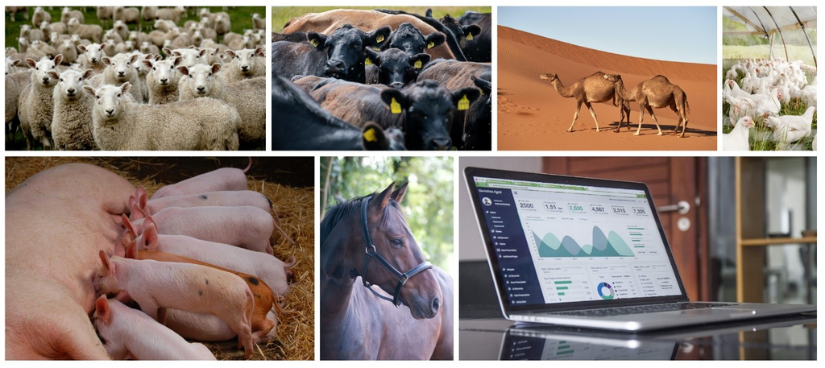

# 1 About this document

In this document you will find indications on how to use various `R` libraries and functions for estimating true disease prevalence and accuracy of diagnostic tests in a Bayesian framework, along with various exercises. We suppose that you do have some basic `R` skills. If you have not worked with `R` before or feel a bit rusty, here are some resources to help you to prepare:

- Chapters 1, 2, and 4 of the [CodeCademy “Learn R” course](https://www.codecademy.com/learn/learn-r) will provide a good overview of the basic concepts required for this workshop.
- If you are familiar with `R` and want to do some further reading, [Hadley Wickham’s “R for Data Science”](https://r4ds.had.co.nz/) is a great resource.

Remember, there are often many different ways to conduct a given piece of work in `R`. Throughout this document, we tried to stick with the simpler approaches (e.g., the shortest code, the minimal number of `R` libraries).

## 1.1 Some notation

Throughout the document, you will find examples of `R` code along with comments. **The `R` code used always appear in grey boxes** (see the following example). This is the code that you will be able to use for your own analyses. **Lines that are preceded by a # sign are comments**, they are skipped when `R` reads them. Following each grey box with `R` code, a **white box with results from the analysis is presented**.

For instance, this is a `R` code where I am simply asking to show main descriptive statistics for the *speed* variable of the *cars* dataset (note that this dataset is already part of `R`).

```r
#This is a comment. R will ignore this line

#The summary() function can be use to ask for a summary of various R objects. For a variable (here the variable speed), it shows descriptive statistics.
summary(cars$speed)
```

```
##    Min. 1st Qu.  Median    Mean 3rd Qu.    Max.
##     4.0    12.0    15.0    15.4    19.0    25.0
```

Throughout the document, in the text we will use:  
- Italics for datasets or variables. For instance, the *speed* variable of the dataset *cars*.  
- Shaded boxes for `R` libraries (e.g., `episensr`) and functions (e.g., `summary()`).

In `R` we can first call a given library and then use the functions related to this library or we can type the name of the library followed by `::` and then the function. For instance the two following pieces of code are equivalent:

```r
library(ggplot2)
ggplot(data=cars, mapping=(aes(x=speed)))+
  geom_histogram()

##OR##

ggplot2::ggplot(data=cars, mapping=(aes(x=speed)))+
  geom_histogram()
```

The latter may improve reproducibility, but at the expense of longer codes. Throughout the document, we will always first call the library and then run the functions to keep codes short.

One last thing, when using a given function, it is not mandatory to name all the arguments, as long as they are presented in the sequence expected by this function. For instance, the `ggplot()` function that we used in the previous chunk of code is expecting to see first a dataset (`data=`) and then a mapping attribute (`mapping=`) and, within that mapping attribute a x variable (`x=`). We could shorten the code by omitting all of these. The two following pieces of code are, therefore, equivalent:

```r
library(ggplot2)
ggplot(data=cars, mapping=(aes(x=speed)))+
  geom_histogram()

##OR##

library(ggplot2)
ggplot(cars, (aes(speed)))+
  geom_histogram()
```

Throughout the document, however, we will use the longer code with all the arguments being named. Since you are learning these new functions, it would be quite a challenge to use the shorter code right from the start. But you could certainly adopt the shorter codes later on.

**LET’S GET STARTED!**

# 2 Distributions

When using latent class models (**LCM**) to estimate disease prevalence or diagnostic test accuracy, we will need to use various distributions. There are two situations where we will use distributions:

1. as prior distributions to describe our *a priori* knowledge on a given unknown parameter.
2. as a part of the likelihood function that will be used to linked observed data with unknown parameters.

Some distributions will more often be used for the first objective, others will mainly be used for the latter objective. In the following sections, we will cover the most useful distributions.

## 2.1 Prior distributions

One of the first things that you will need for any Bayesian analysis is a way to generate and visualize a prior distribution corresponding to some scientific knowledge that you have about an unknown parameter. Generally, you will use information such as the mean and variance or the mode and the 2.5th (or 97.5th) percentile to find a corresponding distribution. Here we present three of the most important distributions. We will give more details on each of them in the following sections:

**- Normal distribution:** defined by a mean (*mu*) and its standard deviation (*SD*) or variance (*tau*). In some `R` packages and software, `rjags` and JAGS for instance, the inverse of the variance (*1/tau*) is used to specify a given normal distribution.  
**Notation: dNorm(*mu*, *1/tau*)**

**- Uniform distribution:** defined by a minimum (*min*) and maximum (*max*).  
**Notation: dUnif(*min*, *max*)**

**- Beta distribution:** bounded between 0 and 1, beta distributions are defined by two shape parameters (*a*) and (*b*).  
**Notation: dBeta(*a*, *b*)**

### 2.1.1 Normal distribution

The `dnorm()` function can be used to generate a given Normal distribution and the `curve()` function can be used to visualize the generated distribution. These functions are already part of `R`, there is no need to upload a `R` package.

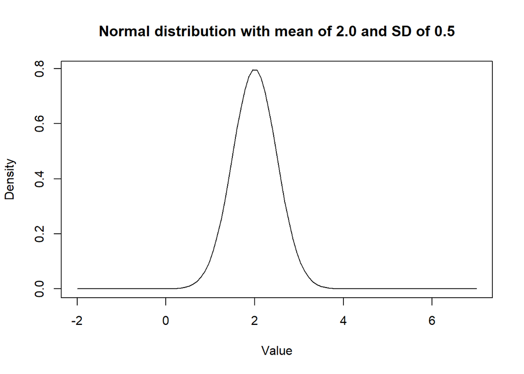

Density curve of a Normal distribution.

```r
curve(dnorm(x, mean=2.0, sd=0.5),                                    # I indicate mean and SD of the distribution
      from=-2, to=7,                                                 # I indicate limits for the plot
      main="Normal distribution with mean of 2.0 and SD of 0.5",     #Adding a title
      xlab = "Value", ylab = "Density")                              #Adding titles for axes
```

Note that a Normal distribution with mean of zero and a very large *SD* provides very little information. Such distribution would be referred to as **uniform or flat distribution** (A.K.A.; a vague distribution).

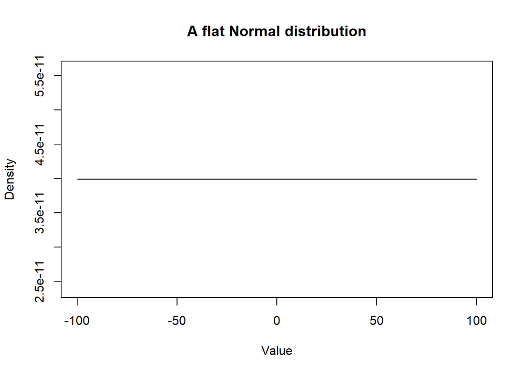

Density curve of a flat Normal distribution.

```r
curve(dnorm(x, mean=0.0, sd=10000000000),
      from=-100, to=100,
      main="A flat Normal distribution",
      xlab = "Value", ylab = "Density")
```

### 2.1.2 Uniform distribution

In the same manner, we could visualize a uniform distribution using the `dunif()` function. In the following example, we assumed that any values between -5.0 and 5.0 are equally probable.

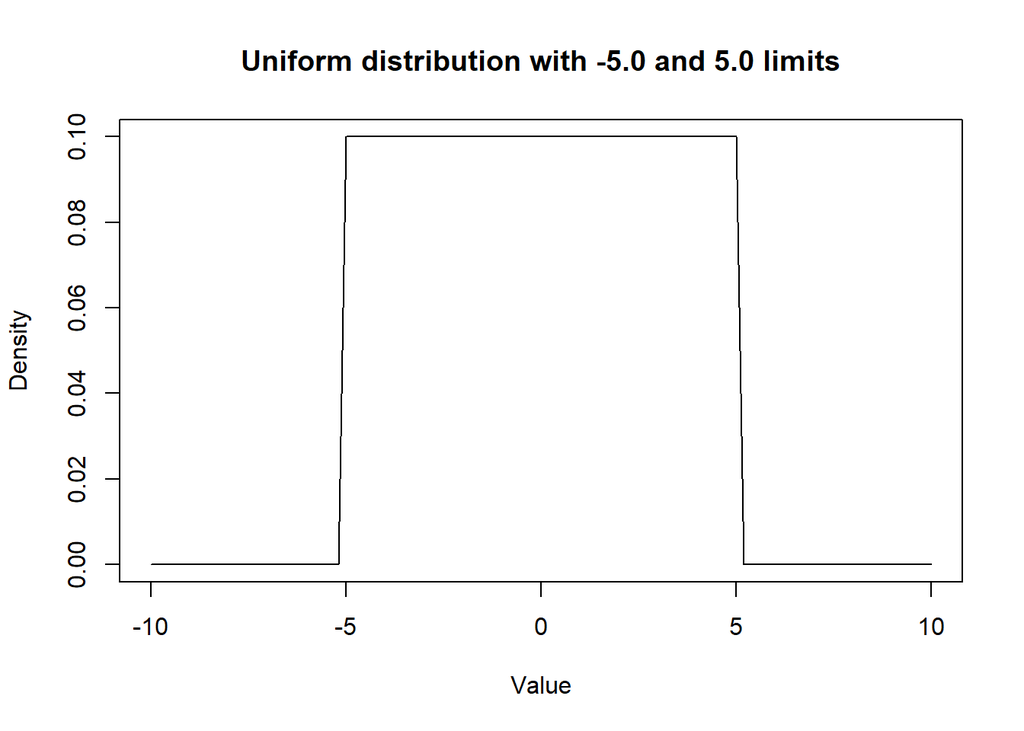

Density curve of a Uniform distribution.

```r
curve(dunif(x, min=-5.0, max=5.0),
      from=-10, to=10,
      main="Uniform distribution with -5.0 and 5.0 limits",
      xlab = "Value", ylab = "Density")
```

### 2.1.3 Beta distribution

Beta distributions are another type of distributions that will specifically be used for parameters that are proportions (i.e., bounded between 0.0 and 1.0). **For this specific workshop, they will be very handy, since sensitivity, specificity, and prevalence are all proportions** . The `epi.betabuster()` function from the `epiR` library can be used to define a given prior distribution based on previous knowledge. When you use the `epi.betabuster()` function, it creates a new `R` object containing different elements. Among these, one element will be named *shape1* and another *shape2*. These correspond to the *a* and *b* shape parameters of the corresponding Beta distribution.

For instance, we may know that the most likely value for the sensitivity of a given test is 0.85 and that we are 97.5% certain that it is greater than 0.75. With these values, we will be able to find the a and b shape parameters of the corresponding Beta distribution. **Within the `epi.betabuster()` function, the `greaterthan=` argument will be important to indicate whether the next argument `x=0.75` describe the 2.5th (`greaterthan=T`) or the 97.5th (`greaterthan=F`) percentile.**

```r
library(epiR)

# Sensitivity of a test as Mode=0.85, and we are 97.5% sure >0.75
rval <- epi.betabuster(mode=0.85, conf=0.975, greaterthan=T, x=0.75)  # I create a new object named rval

rval$shape1                #View the a shape parameter in rval
```

```
## [1] 62.661
```

```r
rval$shape2                #View the b shape parameter in rval
```

```
## [1] 11.88135
```

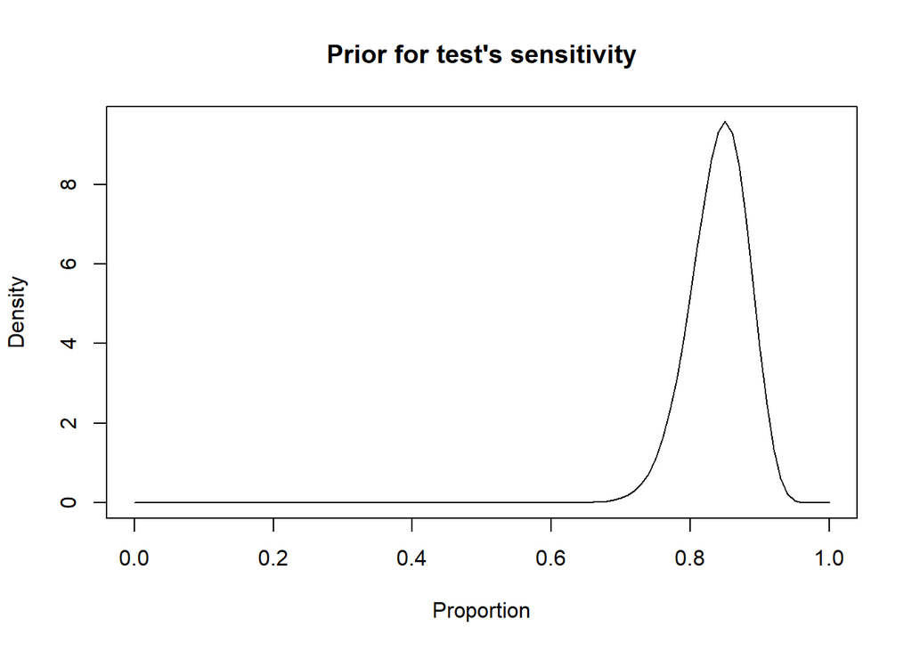

Density curve of a Beta distribution for a test sensitivity.

```r
#plot the prior distribution
curve(dbeta(x, shape1=rval$shape1, shape2=rval$shape2), from=0, to=1,
      main="Prior for test's sensitivity", xlab = "Proportion", ylab = "Density")
```

Note that a dBeta(1.0, 1.0) is a uniform beta distribution.

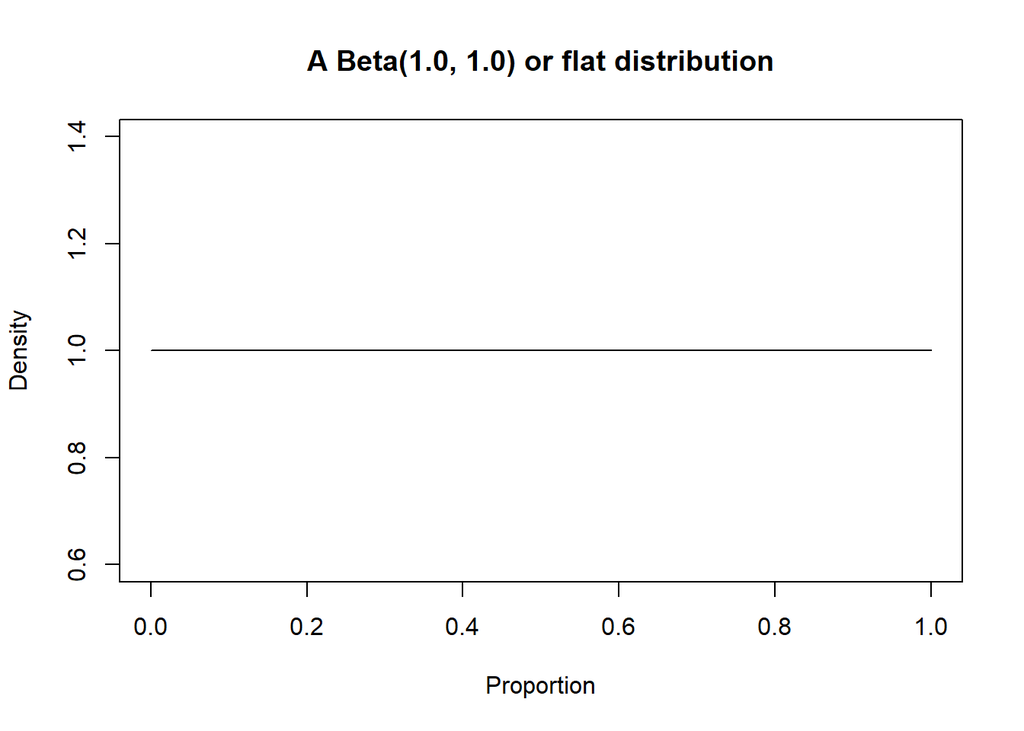

Density curve of a Beta(1.0, 1.0) distribution.

```r
#plot the prior distribution
curve(dbeta(x, shape1=1.0, shape2=1.0), from=0, to=1,
      main="A Beta(1.0, 1.0) or flat distribution", xlab = "Proportion", ylab = "Density")
```

## 2.2 Distributions for likelihood functions

In many situations, a distribution will be used as a part of the likelihood function to link observed data to unknown parameters. The ones we will most frequently use are:

**- Binomial distribution:** For variables that can take the value 0 or 1. Binomial distributions are defined by the probability that the variable takes the value 1, (*P*), and a number of “trials”, (*n*).  
**Notation: dBin(*P*, *n*)**

**- Multinomial distribution:** made up of a number of probabilities, all bounded between 0 and 1, and that, together, will sum up to 1. Multinomial distributions are defined by k probabilities (*P1*, *P2*, …, *Pk*) and the number of observations (*n*).  
**Notation: dmulti(*P[1:k]*, *n*)**

### 2.2.1 Binomial distribution

If we have a variable that can take only two values, healthy or diseased (0 or 1), we can estimates an unknown parameter such as the proportion (*P*) of diseased individuals (i.e., the disease prevalence), based on the observed data (a number of positive individuals, *T* AND a total number of individuals, *n*). For instance, if we had 30 diseased (*T* = 30) out of 100 tested individuals (*n*=100) we could estimate the unknown parameter *P* using this very simple likelihood function:

$T \sim dbin(P, n)$

### 2.2.2 Multinomial distribution

A last type of distribution that we will use in our LCM is the multinomial distribution. When an outcome is categorical with >2 categories, we could use a multinomial distribution to describe the probability that an individual has the value “A”, or “B”, or “C”, etc. In our context, the main application of this distribution will be for describing the combined results of two (or more than two) diagnostic tests. For instance, if we cross-tabulate the results of Test A and Test B, we have four potential outcomes:

-Test A+ and Test B+ (lets call *n1* the number of individuals with that combination of tests results and *P1* the probability of falling in that cell)  
-Test A+ and Test B- (*n2* and *P2*)  
-Test A- and Test B+ (*n3* and *P3*)  
-Test A- and Test B- (*n4* and *P4*)

We can illustrate this as follow:

Cross-classified results from two diagnostic tests

|  | Test A+ | Test A- |
| --- | --- | --- |
| Test B+ | n1 | n3 |
| Test B- | n2 | n4 |

Thus we could describe the probabilities (*P1* to *P4*) of an individual falling into one of these cells of the 2x2 table as a multinomial distribution. In this specific case, we would say that the combined results of the 2 tests (*n1* to *n4*) and the total number of individual tested (*n*), which are the observed data, are linked to the 4 probabilities (*P1* to *P4*; the unknown parameters) as follows:

$n[1:4] \sim dmulti(P[1:4], n)$

Which means: the value of *n1* (or *n2*, *n3*, or *n4*) is determined by the probability of falling into the “Test A+ and Test B+” cell, which is *P1* (or *P2*, *P3*, or *P4* for the other cells), and by the total number of individuals tested (*n*). Nothing too surprising here… If I have a probability of 0.30 to fall in a given cell, and I have tested 100 individuals, I should find 30 individuals in that cell. Wow! Still, the multinomial distribution is nice because it will ensure that all our probabilities (*P1* to *P4*) will sum up to exactly 1.0.

# 3 Running Bayesian models

Different software and `R` packages can be used to run Bayesian models. Whether it is a LCM or a more conventional regression model is not very important at this stage. In this document we will mainly use a software called JAGS and the `R2jags` package. **So, if not already done, you will have to download JAGS [here](https://sourceforge.net/projects/mcmc-jags/files/) and install it on your computer.** Once installed, we will be able to use `R2jags` to operate JAGS through `R`.

Basically, to run any Bayesian model, we will always need the same three things:

- Data
- A model containing:
  - A likelihood function linking observed data to unknown parameters
  - A prior distribution for each unknown parameter
- An initial value for each unknown parameters to start the Markov chains
  - These values can also be generated randomly by the software, but specifying them will improve reproducibility

## 3.1 The data

This is the easy part. If we were to run, for instance, a “conventional” regression analysis, we would have to import in `R` a complete dataset (e.g., a CSV file) with a row for each observation and a column for each variable. However, when using LCM to estimate a disease prevalence or diagnostic accuracy, the dataset is simply made up of the number of individuals in each category. For instance, to estimate a simple prevalence (*Prev*), we could have 30 individuals that tested positive (variable *T*) out of a total of 100 individuals (variable *n*). In such case, the dataset could be created as follow:

```r
#Creating a dataset
datalist <- list(T=30, n=100)
```

If you want to check that it works, you could ask to see this new `R` object.

```r
datalist
```

```
## $T
## [1] 30
##
## $n
## [1] 100
```

## 3.2 The model

### 3.2.1 The likelihood function

Let’s start with a simple example, estimating a single proportion. For estimating a proportion we could describe the likelihood function linking unknown parameters to observed data as follows:

$T \sim dbin(Prev, n)$

In other words: the disease prevalence (*Prev*), an unknown parameter, can be linked to the observed number of positive individuals (*T*) and the total number of tested individual (*n*) through the binomial function.

In this case, the values of *T* and *n* are the observed data and *Prev* is the only unknown parameter.

### 3.2.2 Priors for unkown parameters

We will have to specify a prior distribution for each unknown parameter (using the $\sim$ sign).

In the preceding example, we only have one unkown parameter, *Prev*, which is a proportion. Theoretically such parameter could take values from 0 to 1, so a beta distribution would be one way to describe its prior distribution. We could use the `epi.betabuster()` function from the `epiR` library to define a given beta distribution based on previous knowledge, as described in the preceding sections. Moreover, if we want to use a flat prior, we could simply choose the value 1.0 for the a and b shape parameters.

In the following code, I am creating `R` objects for a and b for *Prev* beta prior distributions.

```r
Prev.shapea <- 1         #a shape parameter for Prev
Prev.shapeb <- 1         #b shape parameter for Prev
```

With informative priors, for instance, if we know from the literature that the prevalence is expected to be 0.25 with 95CI of (0.20, 0.30), we could instead use the following code and assign these values to *Prev.shapea* and *Prev.shapeb*:

```r
library(epiR)

# Prevalence as Mode=0.25, and we are 97.5% sure >0.20
rval <- epi.betabuster(mode=0.25, conf=0.975, greaterthan=T, x=0.20)  # I create a new object named rval

rval$shape1                #View the a shape parameter in rval
```

```
## [1] 62.356
```

```r
rval$shape2                #View the b shape parameter in rval
```

```
## [1] 185.068
```

```r
#I left them as comments, but the two lines below would be used to assign the generated values for later usage
#Prev.shapea <- rval$shape1
#Prev.shapeb <- rval$shape2
```

### 3.2.3 Creating the JAGS model

Our Bayesian model has to be presented to JAGS as a text file (i.e., a .txt document). To create this text file, we will use the `paste0()` function to write down the model and then the `write.table()` function to save it as a .txt file.

**An interesting feature of the `paste0()` function is the possibility to include `R` objects in the text.** For instance, you may want to have a generic model that will not be modified, but within with you would like to change the values used to describe the priors. You could include these “external” values Within your `paste0()` function. Thus, you just have to change the value of the `R` object that your model is using, rather than rewriting a new model. For instance, we just created these two `R` objects called *Prev.shapea* and *Prev.shapeb* (which were the a and b shape parameters for the prior distribution of our proportion *Prev*). To describe our prior distribution, we can ignore this previous work that we have done and directly create a short text as follows:

```r
text1 <- paste0("Prev ~ dbeta(1, 1)")       #Creating a short text named "text1"
text1                                       #Asking to see the text1 object
```

```
## [1] "Prev ~ dbeta(1, 1)"
```

However, if the same model is to be applied later with a different prior distribution, it may be more convenient to leave the *a* and *b* shape parameters as `R` objects. Thus, if we change the prior distribution and run the script again, you would run the entire analyses with the newly created distribution.

```r
text2 <- paste0("Prev ~ dbeta(",Prev.shapea,", ",Prev.shapeb,")")            #Creating a short text named "text2" and containing other already created R objects
text2                                                                        #Asking to see the text2 object
```

```
## [1] "Prev ~ dbeta(1, 1)"
```

When using `paste0()`, any text appearing outside of sets of quotation marks (e.g., *Prev.shapea* and *Prev.shapeb* in the preceding script) will be considered as `R` objects that need to be included in the text. Thus, later, I could just change the values for *Prev.shapea* and *Prev.shapeb* and my model will be automatically modified.

**Some important notes about the text file containing the model before we start with `R2jags`:**

- JAGS is expecting to see the word “model” followed by curly brackets { }. The curly brackets will contain the likelihood function AND the priors.
- Similarly to `R`, any line starting with a # will be ignored (these are comments).
- Similarly to `R`, <- means equal.
- The ~ symbol means “follows a distribution”.
- Similarly to `R`, JAGS is case sensitive (i.e., *P* does not equal *p*).
- Loops can be used with keyword “for” followed by curly brackets.
- Array can be indicated using squared brackets [ ].

In the example below, I create a `R` object called *model_single_prop* using the `paste0()` function and then save it as a text file using the `write.table()` function. We will check this text file below and then explain the code for the model.

```r
# Specify the model
model_single_prop <- paste0("model{

#=== LIKELIHOOD ===#

  T ~ dbin(Prev, n)


#=== PRIOR  ===#

  Prev ~ dbeta(",Prev.shapea,", ",Prev.shapeb,")    ## Prior for Prev

}")

#write as a text (.txt) file
write.table(model_single_prop,
            file="model_single_prop.txt",
            quote=FALSE,
            sep="",
            row.names=FALSE,
             col.names=FALSE)
```

Here is a snapshot of the final result (i.e., the text file):

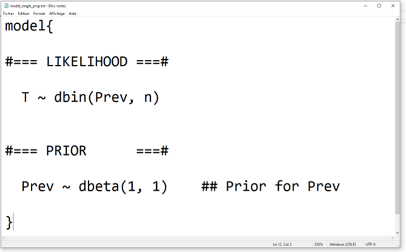

Text file with the model for estimating a single proportion.

## 3.3 Generating initial values

The initial value is the first value where each Markov chain will start.  
- You have to specify one initial value for each unknown parameter in the model.  
- If you decide to run three Markov chains, you will need three different sets of initial values. - You can also let the software choose a random value to start each chain, but it will then be impossible to **exactly** reproduce a given result. For instance, if you have obtained a very ackward Markov chain, you may not be able to reproduce this result to investigate what went wrong. Note, though, that it would be quite uncommon for a Markov chain to be “sensitive” to the chosen starting value. But you will see during the workshop that it will sometimes happen.

In our preceding example we have one unknown parameter (*Prev*). If we were to run three Markov chains, we could generate three sets of initial values for this parameter as follows. Of course, the chosen values could be changed. In the case of a proportion, you can specify any value between 0 and 1.

```r
#Initializing values for the parameter "Prev" for the 3 chains
inits <- list(
  list(Prev=0.10),
  list(Prev=0.50),
  list(Prev=0.90)
  )
```

We know have a `R` object called *inits* that contains the three values where each Markov chains will start from.

## 3.4 Running a model in JAGS

We now have the three elements that we needed: the data, the model, and a set of initial values. We can now use the `R2jags` library to run our Bayesian analysis. The `R2jags` package provides an interface from `R` to the JAGS software for Bayesian data analysis. JAGS uses Markov Chain Monte Carlo (**MCMC**) simulation to generate a sample from the posterior distribution of the parameters.

The `R2jags` function that we will use for that purpose is the `jags()` function. Here are the arguments that we need to specify:

- The dataset using `data=`
- The text file containing the model written in JAGS code using `model.file=`
- The names of the parameters which should be monitored using `parameters.to.save=`
- The number of Markov chains using `n.chains=`. The default is 3
- The sets of initial values using `inits=`. If inits is NULL, JAGS will randomly generate values
- The number of total iterations per chain (including burn-in; default: 2000) using `n.iter=`
- The length of burn-in (i.e., number of iterations to discard at the beginning) using `n.burnin=`
- The thinning rate, which represent how many of the values sampled by the MCMC will be retained. The default is 5 (1 out of 5). Since there is no *a priori* need for thinning, you can specify `n.thin`=1 in most situations
- The last argument `DIC=TRUE` or `DIC=FALSE` will determine whether to compute the deviance, pD, and deviance information criteria (**DIC**). These could sometimes be useful for model selection/comparison. We could leave that to `DIC=FALSE` since we will not be using these values during the workshop

With the following code, we will create a `R` object called *bug.out*. This object will contain the results of running our model with the specified priors using the available data, and the sets of initial values that we have created. For this analysis, we have asked to run 3 Markov chains for 6000 iterations each and we discarded the first 1000 iterations of each chain. Finally, we will monitor our only unknown parameter: *Prev* and nothing else.

```r
library(R2jags)
library(coda)

#Run the Bayesian model
bug.out <- jags(data=datalist,                             #Specifying the R object containing the data
               model.file="model_single_prop.txt",         #Specifying the .txt file containing the model
               parameters.to.save=c("Prev"),               #Specifying the parameters to monitor. When >1 parameter, it will be a list, ex: c("Prev", "Se", "Sp")
               n.chains=3,                                 #Number of chains
               inits=inits,                                #Specifying the R object containing the initial values
               n.iter=6000,                                #Specifying the number of iterations
               n.burnin=1000,                              #Specifying the number of iterations to remove at the begining
               n.thin=1,                                   #Specifying the thinning rate
               DIC=FALSE)                                  #Indicating that we do not request the deviance, pD, nor DIC
```

## 3.5 Model diagnostic

Before jumping to the results, you should first check if:  
- The chains have converged,  
- The burn-in period was long enough,  
- You have a large enough sample of values to describe the posterior distribution with sufficient precision,  
- The Markov chains behaved well (mainly their auto-correlation).

There are many diagnostic methods available for Bayesian analyses, but, for this workshop, we will mainly use basic methods relying on plots.

Diagnostics are available when you convert your model output into a MCMC object using the `as.mcmc()` function of the `mcmcplots` library.

```r
library(mcmcplots)
bug.mcmc <- as.mcmc(bug.out)          #Converting the model output into a MCMC object (for diagnostic plots)
```

You can then use the `mcmcplot()` function on this newly created MCMC object.

```r
mcmcplot(bug.mcmc, title="Diagnostic plots")        #Asking for the diagnostic plots
```

When you do that, a HTML document will be created and your web browser will automatically open it. Here is a snapshot of the HTML file in my browser:

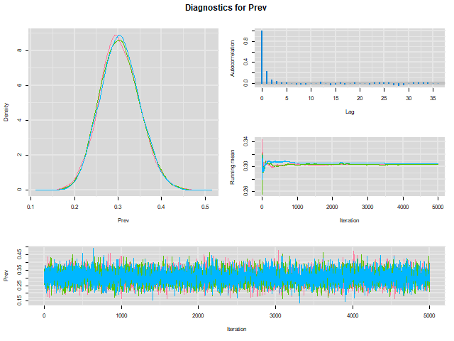

**Figure.** Diagnostic plots.

### 3.5.1 Convergence and burn-in

To check whether convergence of the Markov chains was achieved you can inspect the “trace plot” (the bottom figure) presenting the values that were picked by each chain on each iteration. The different chains that you used (three in the preceding example) will be overlaid on the trace plot. You should inspect the trace plot to **evaluate whether the different chains all converged in the same area**. If so, after a number of iterations they should be moving in a relatively restricted area and this area should be the same for all chains.

The plots above would be a good example of the trace plot of three “nice” Markov chains (lucky us!). In this preceding example, we can see on the trace plot that the chains had already converged (probably way before the end of the first 1000 iterations that were excluded) toward the same area. On the trace plot, we can only see the values that were stored after the burn-in period. The chains were then moving freely within this limited area (thus sampling from the posterior distribution).

We could conclude based on the trace plot that:  
- The Markov chains did converge  
- A short burn-in period of less than a 1000 iterations would have been sufficient. Note that we will often use a longer burn-in (e.g., 5,000 or even more) just to be sure and because it only costs a few more seconds on your computer…

Here is another example where two chains (the red and green) converged in the same area, but a third one (the blue) also converged, but in a different area. **We should be worried in such case**. We will see later the reason for such behavior.

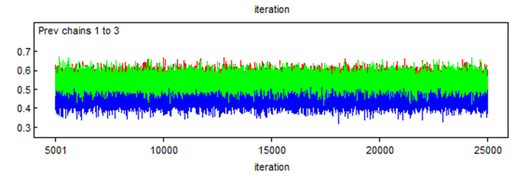

Finally, here is a last example with just one Markov chain which clearly did not converge, even after 25,000 iterations. **You should be terrified by that!!! ;-)**.

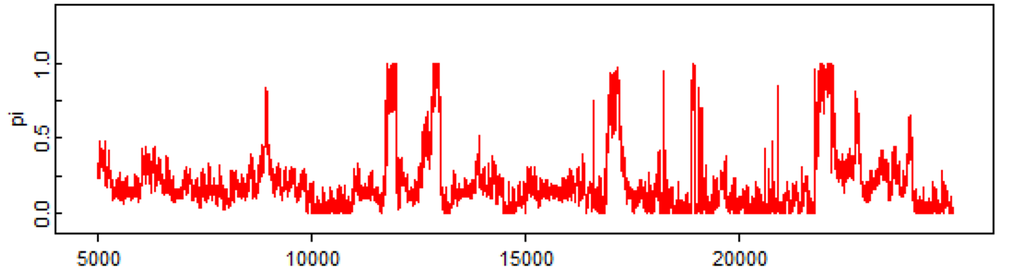

### 3.5.2 Number of iterations

Next, you can inspect the posterior distributions to determine if you have a large enough sample of independent values to describe with enough precision the median estimate and the 2.5th and 97.5th percentiles. The effective sample size (**EES**) takes into account the number of values generated by the Markov chains **AND** whether these values were auto-correlated, to compute the number of “effective” independent values that are used to describe the posterior distribution. Chains that are auto-correlated will generate a smaller number of “effective values” than chains that are not auto-correlated.

The `effectiveSize()` function of the `coda` library provide a way to appraise whether you add enough iterations. In the current example, we already created a `mcmc` object named `bug.mcmc`. We can ask for the effective sample size as follow:

```r
effectiveSize(bug.mcmc)         #Asking for the ESS
```

```
##     Prev
## 8918.203
```

So we see here that, despite having stored 3 times 5,000 values (15,000 values), we have the equivalent of almost 9,000 independent values. What to do with this information? Well, you could, for instance, decide on an arbitrary rule for ESS (say 10,000 values) and then adapt the length of the chains to achieve such an ESS (for each of the selected parameters, because the effective sample sizes will not be the same for all parameters).

### 3.5.3 Auto-correlation

Remember, a feature of Markov chains is to have some auto-correlation between two immediately subsequent iterations and then a correlation that quickly goes down to zero (i.e., they have a short memory). The auto-correlation plot can be used to assess if this feature is respected.

From our previous example (check the upper right figure in the plot below), it seems that it is the case.

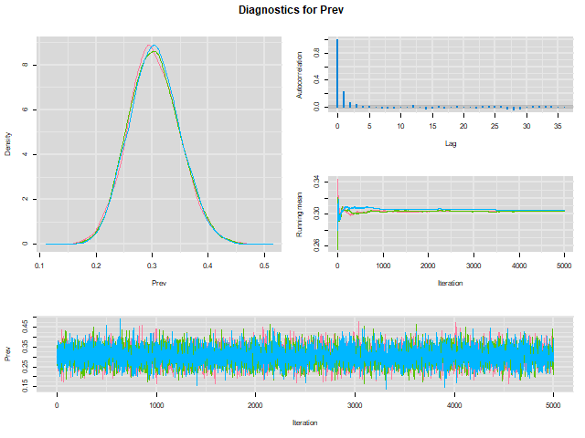

Here is another example were we do have an auto-correlation that is persisting.

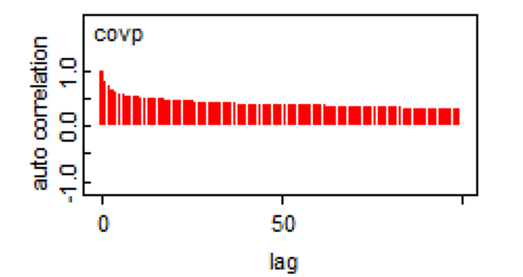

When such a behavior is observed, running the chains for more iterations will help achieve the desire ESS. In some situations, specifying different priors (i.e., increasing the amount of information in priors) may also help.

## 3.6 Getting our estimates

Now, if you are happy with the behavior of your Markov chains, the number of iterations, and burn-in period, you can summarize your results (i.e., report the median, 2.5th and 97.5th percentiles) very easily with the `print()` function. Below, I have also indicated `digits.summary=3` to adjust the precision of the estimates that are reported (the default is 1).

```r
print(bug.out,                  #Asking to see the mean, median, etc of the unknown parameters that were monitored
      digits.summary=3)         #Requiring a precision of 3 digits
```

```
## Inference for Bugs model at "model_single_prop.txt", fit using jags,
##  3 chains, each with 6000 iterations (first 1000 discarded)
##  n.sims = 15000 iterations saved
##      mu.vect sd.vect 2.5%   25%   50%   75% 97.5%  Rhat n.eff
## Prev   0.305   0.045 0.22 0.273 0.303 0.334 0.398 1.001 12000
##
## For each parameter, n.eff is a crude measure of effective sample size,
## and Rhat is the potential scale reduction factor (at convergence, Rhat=1).
```

You can also ask for plotting the *bug.mcmc* object that you have created using the `plot()` function. It would produce the trace plot and a density plot presenting the posterior distributions of each unknown parameter.

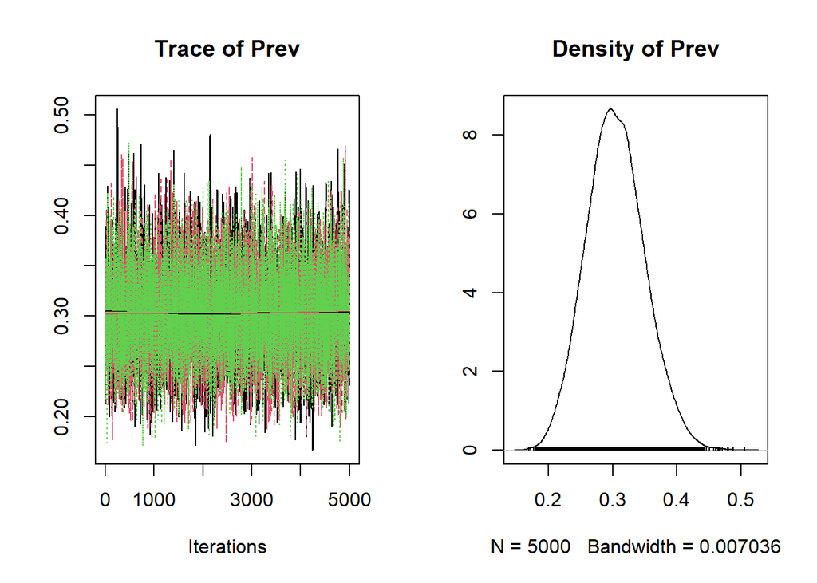

Trace plot and density plot produced using the plot() function.

```r
plot(bug.mcmc)              #Asking for trace plot and plots of prior and posterior distributions
```

If you prefer to work on your own plots, note that all the values sampled from your posterior distributions were stored in the *bug.out* object that you have created. If you inspect the *bug.out* object, you will notice an element named *BUGSoutput*, inside this element, there is another object named *sims.list*, within this *sims.list*, there is an element named *Prev*. As you can see below, this element is made of a list of 15,000 values. This correspond to the 5,000 values sampled (1/iteration) by each Markov chain (3 chains) for the unknown parameter *Prev*. **So this element is simply all the sampled values assembled together**.

[figure not shown]

sims.list object located in the *bug.out* output.

You could use this element, for instance, to plot together the prior and posterior distributions on a same figure. On the figure below, the prior distribution is not obvious, it is the flat dashed red line just above the x axis (remember, we used a flat prior for *Prev*).

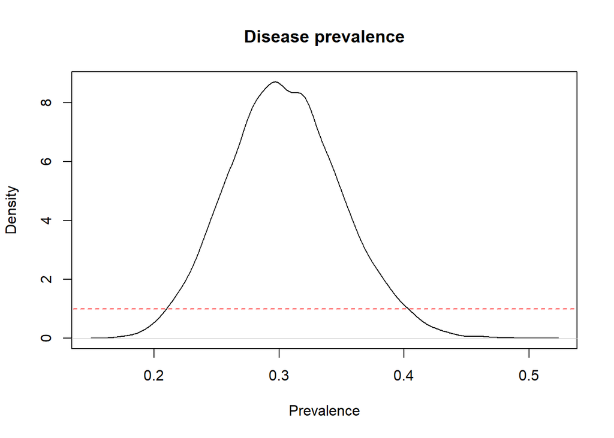

Prior (dashed red line) and posterior (full black line) distribution of the prevalence of disease.

```r
#Plot the posterior distribution
plot(density(x=bug.out$BUGSoutput$sims.list$Prev),      #Indicating variable to plot
     main="Disease prevalence",                         #Title for the plot
     xlab="Prevalence", ylab="Density",                 #x and y axis titles
     )

#plot the prior distribution
curve(dbeta(x, shape1=Prev.shapea, shape2=Prev.shapeb), from=0, to=1,          #Plotting the corresponding prior distribution
      lty=2,                                                                   #Asking for a dashed line pattern
      col="red",                                                               #Asking for a red line
      add=TRUE)                                                                #Asking to add this plot to the preceding one
```

# 4 Exercise 1 - Proportions

## 4.1 Data

The data used for the following exercises came from a study aiming at estimating diagnostic accuracy of a milk pregnancy associated glycoprotein (**PAG**) ELISA and transrectal ultrasonographic (**US**) exam when used for determining pregnancy status of individual dairy cows 28 to 45 days post-insemination. In that study, the new test under investigation was the PAG test and US was used for comparison, but was considered as an imperfect reference test.

In the original study, data from 519 cows from 18 commercial dairy herds were used. For the following exercises, the dataset was modified so that we have data from 519 cows from 3 herds (i.e., the data from 16 herds were collapsed together so they appear to be from one large herd). Note that there are some cows with missing values for one of the tests, so we will not always work with 519 cows. The complete original publication can be found here: [Dufour et al., 2017](https://www.sciencedirect.com/science/article/pii/S016758771630527X?casa_token=jmHY9HiOdEYAAAAA:kGdiIujRzrAQjjFRbGqtUxIBalDGvXllp6ja9w4T2s6c7yPbgc0asnak79bJ5GWWXI8InhCg0sg).

The dataset *Preg.xlsx* contains the results from the study. However, **for the exercises we will always simply use the cross-tabulated data and these will be already organized for you and presented at the beginning of each exercise**. The dataset is still provided so you can further explore additional comparisons. The list of variables in the *Preg.xlsx* dataset are described in the table below.

**Table**. List of variables in the *Preg.xlsx* dataset.

| **Variable** | **Description** | **Range** |
| --- | --- | --- |
| Obs | An observation unique ID number | 1 to 519 |
| Herd | Herd ID number | 1 to 3 |
| Cow | Cow ID number | NA |
| T1_DOP | Number of days since insemination at testing | 28 to 45 |
| PAG_DX | Results from the PAG test | 0 (not pregnant); 1 (pregnant) |
| US_DX | Results from the ultrasound test | 0 (not pregnant); 1 (pregnant) |
| TRE_DX | Results from the transrectal exam (TRE) test | 0 (not pregnant); 1 (pregnant) |

## 4.2 Questions

We will use data from one population (herd #1). In this herd, we had the following proportion of apparently pregnant cows (based on the US exam).

**139 US+/262 exams**

Open up the `R` project for Exercise 1 (i.e., the R project file named *Exercise 1.Rproj*).

In the Exercise 1 folder, you will find partially completed `R` scripts. To answer the questions, try to complete the missing parts (they are highlighted by a **#TO COMPLETE#** comment). We also provided complete `R` scripts, but try to work it out on your own first!

**1. Start from the partially completed *Question 1.R* script located in Exercise 1 folder.** What would be the proportion of pregnant cows? Use a Bayesian approach to compute that proportion and a credible interval (**CI**). For this first computation, assume that you have no prior knowledge on the expected proportion of pregnant cows in a Canadian herd. Run three Markov chains with different sets of initial values. Look at the trace plot. Do you think convergence was achieved? Do you need a longer burn-in period? Are all 3 chains converging in the same space? Compute the effective sample size (**ESS**), do you feel that number of iterations was sufficient to describe the posterior distribution with enough precision? What about auto-correlation of the Markov chains, any issues there?

**2.** If you were to compute a Frequentist estimate with 95% CI, would it differ a lot from your Bayesian estimates? Why? As a refresher, the formula for a Frequentist 95%CI for a proportion is below (where *P* is the actual observed proportion and *n* is the denominator for that proportion):

$95CI=P \pm 1.96* \sqrt{\frac{P*(1-P)}{n}}$

**3. Start from the `R` script that you completed in Question 1.** In the literature, you saw a recent study conducted on 30 Canadian herds and reporting an expected pregnancy prevalence of 42% with 97.5% percentile of 74%. What kind of distribution could you use to represent this information? Use these information as a pregnancy prevalence prior distribution. Are your results very different?

**4. Start from the partially completed *Question 4.R* script located in Exercise 1 folder.** When comparing PAG to US results in herd #1, you got the following 2x2 table.

**Table.** Cross-classified results of the PAG and US tests in herd #1.

|  | **US+** | **US-** | **Total** |
| --- | --- | --- | --- |
| **PAG+** | 138 | 10 | 148 |
| **PAG-** | 1 | 113 | 114 |
| **Total** | 139 | 123 | 262 |

Assuming that US is a gold-standard test could you compute PAG sensitivity (**Se**) and specificity (**Sp**)? Use vague priors for PAG *Se* and *Sp* since it is the first ever study on this topic (i.e., you do not have any prior knowledge on these unknown parameters).

## 4.3 Answers

**1.** What would be the proportion of pregnant cows? Use a Bayesian approach to compute that proportion and a credible interval (**CI**). For this first computation, assume that you have no prior knowledge on the expected proportion of pregnant cows in a Canadian herd. Run three Markov chains with different sets of initial values. Look at the trace plot. Do you think convergence was achieved? Do you need a longer burn-in period? Are all 3 chains converging in the same space? Compute the effective sample size (**ESS**), do you feel that number of iterations was sufficient to describe the posterior distribution with enough precision? What about auto-correlation of the Markov chains, any issues there?

**Answer:** I chose to run a model with 3 chains of 10,000 iterations each (11,000 iterations minus a burn-in of 1,000). I have obtained the following diagnostic plots:

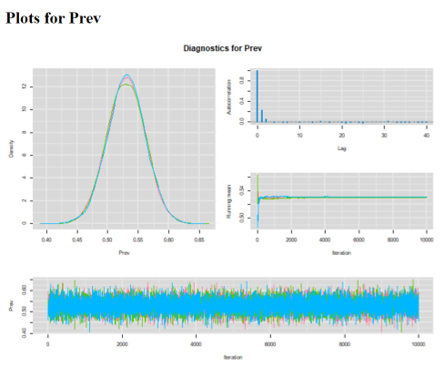

Diagnostic plot

The median pregnancy prevalence estimate (95% CI) was 53.0% (46.9, 59.0).

**2.** If you were to compute a Frequentist estimate with 95% CI, would it differ a lot from your Bayesian estimates? Why?

$P = 139/262 = 0.531$

$95CI=0.531 \pm 1.96* \sqrt{\frac{0.531*(1-0.531)}{262}} = 0.531 \pm 0.060$

Thus, we have a Frequentist estimated proportion of 53.1% with a Frequentist 95 CI of 47.1 to 59.1 (virtually unchanged compared to the Bayesian estimates).

**3.** In the literature, you saw a recent study conducted on 30 Canadian herds and reporting an expected pregnancy prevalence of 42% with 97.5% percentile of 74%. What kind of distribution could you use to represent this information? Use these information as a pregnancy prevalence prior distribution. Are your results very different?

**Answer:** A beta(4.2, 5.4) distribution would have a mode of 0.42 and a 97.5th percentile of 0.74. Using this information as prior, I get a prevalence of pregnancy of 52.7% (95 CI: 46.8, 58.6). Actually, we observe very little difference between the models using vague *vs.* informative priors. This is because this informative prior contains only the equivalent of 10 observations $(4.2+5.4)$. In the dataset, there are 262 cows. Therefore, the estimation process is still mainly driven by our dataset.

**4.** Assuming that US is a gold-standard test could you compute PAG sensitivity (**Se**) and specificity (**Sp**)? Use vague priors for PAG *Se* and *Sp* since it is the first ever study on this topic (i.e., you do not have any prior knowledge on these unknown parameters).

**Answer:** The sensitivity and specificity are simple proportions. Sensitivity is simply the number of test positive among the number of truly diseased individuals. We have data for these in the 2x2 table. If we assume that *US* is a gold-standard test, then the number of truly diseased cows is 139. Of them, 138 tested positive to the *PAG* test. Similarly, the specificity is simply the number of test negative among the number of truly healthy individuals. From the 2x2 table, the number of true negative cows was 123 and 113 of them tested negative to the *PAG* test. The likelihood functions (one for each parameter in this case) linking the unknown parameters (*Se* and *Sp*) to these observed data would be:

$Test+ \sim dbin(Se, True+)$

$Test- \sim dbin(Sp, True-)$

Using vague beta(1, 1) priors on the *Se* and *Sp*, I got an estimated *Se* of 98.8% (95 CI: 96.1, 99.8) and a *Sp* of 91.5% (95CI: 85.9, 95.5). **But be cautious with these numbers.** We know very well that an *US* exam is not a perfect diagnostic test for pregnancy in dairy cows. With the current approach, we are attributing all disagreements between tests to a failure of the *PAG* test… But it could be the *US* test that was wrong in many instances. Moreover, animals for which the two tests agreed could still be misdiagnosed as pregnant or open, but by both tests (i.e., a failure of the *PAG* **AND** the *US* tests). We wil see in the next sections of the course how to account for the fact that neither of the tests are gold-standards.

# 5 Two imperfect tests

When using two imperfect diagnostic tests on a same population, we will have to use a Bayesian latent class model (**LCM**) to estimate the true disease prevalence, and the sensitivity and specificity of both diagnostic tests. Two different approaches could be used. The simplest approach would be to consider that the two diagnostic tests are conditionally independents. Conditional independence can be defined as:

*Two tests are conditionally independent when the sensitivity (or specificity) of one test does not depend on whether the results of another test are positive or negative among infected (or non-infected) individuals.* [Cheung et al., 2021](https://doi.org/10.20506/rst.40.1.3224)

In many situations, however, we will use two diagnostic tests that make use of the same biological process. For instance, an ELISA test could measure antibodies against a given pathogen in blood and another test could also measure antibodies, but in milk. In such case, it would be difficult to pretend that:

*The sensitivity of the milk test does not depend on whether the results of the blood test are positive or negative among infected individuals.*

In such case, it would be better to consider a LCM where conditional dependence between tests is possible. Note that, even for tests that make use of very different biological processes, it is rather difficult (or, actually, often impossible) to “demonstrate” conditional independence between tests. So, if doable, allowing for a potential conditional dependence between tests would be a more robust strategy.

## 5.1 Assuming conditional independence

Let’s first consider two conditionally independent diagnostic tests. When two tests are conditionally independent, then obtaining a given combination of results to Test A and Test B, as function of the true disease prevalence (*P*) and of the accuracy of each test (*SeA*, *SpA*, *SeB*, *SpB*), can be described as illustrated below:

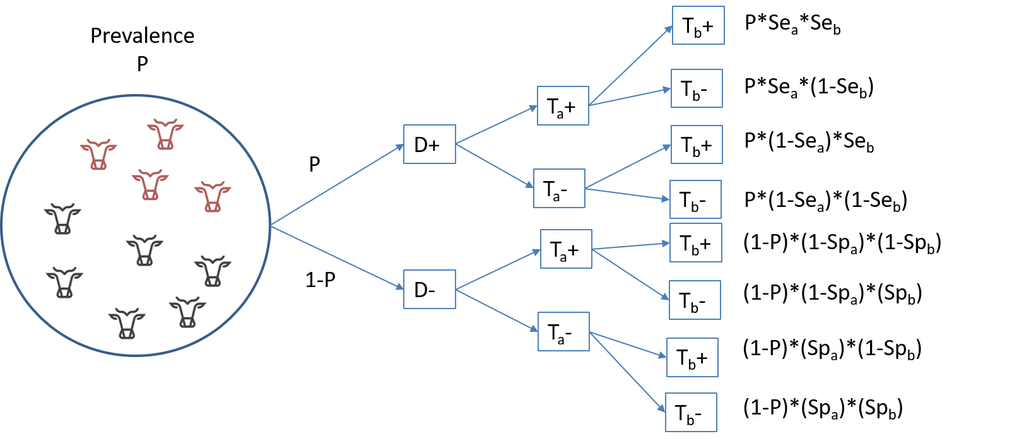

Illustration of the different potential results when applying two conditionally independent tests in a population.

With that illustration, we can deduce that the probability of testing positive to both tests is the sum of the first and fifth rows:

$P(TestA+ TestB+) = P*SeA*SeB + (1-P)*(1-SpA)*(1-SpB)$

Or, putted in words, it is the probability of being a truly diseased individual and of being identified as such by both tests ($P*SeA*SeB$), plus the probability of being a healthy individual and being misdiagnosed as diseased by both tests ($(1-P)*(1-SpA)*(1-SpB)$). If we extend this reasoning to all tests combination possibilities, we get:

$P(TestA+TestB+) = P*SeA*SeB + (1-P)*(1-SpA)*(1-SpB)$  
$P(TestA+TestB-) = P*SeA*(1-SeB) + (1-P)*(1-SpA)*SpB$  
$P(TestA-TestB+) = P*(1-SeA)*SeB + (1-P)*SpA*(1-SpB)$  
$P(TestA-TestB-) = P*(1-SeA)*(1-SeB) + (1-P)*SpA*SpB$

When conducting two diagnostic tests on a given population, the data generated can be presented very simply as the number of individuals in each cells of the 2x2 table presenting the cross-classified results of the two tests:

Cross-classified results from two diagnostic tests

|  | Test A+ | Test A- |
| --- | --- | --- |
| Test B+ | n1 | n3 |
| Test B- | n2 | n4 |

Thus, the likelihood function that could link the observed data (*n1*, *n2*, *n3*, *n4*) to the unknown parameters (*P*, *SeA*, *SeB*, *SpA*, *SpB*) could be defined as follows, using a multinomial distribution:

$n[1:4] \sim dmulti(P[1:4], n)$

$P1 = P*SeA*SeB + (1-P)*(1-SpA)*(1-SpB)$  
$P2 = P*SeA*(1-SeB) + (1-P)*(1-SpA)*SpB$  
$P3 = P*(1-SeA)*SeB + (1-P)*SpA*(1-SpB)$  
$P4 = P*(1-SeA)*(1-SeB) + (1-P)*SpA*SpB$

Again, if we put that in words, the number of individuals in cell *n1* (i.e., TestA+ and TestB+) is determined by the number of individuals tested (*n*) and the probability (*P1*) of falling in that cell. The latter itself depends on the true prevalence of disease in the population (*P*), and on each of the two tests sensitivity (*SeA* and *SeB*) and specificity (*SpA* and *SpB*). We can use similar reasoning for *n2*, *n3*, and *n4*. Finally, the multinomial distribution would further imposed that the four probabilities (*P1*, *P2*, *P3*, and *P4*) have to sum up to 1.0 (i.e., 100%).

To run such a model, we simply need to provide a dataset where *n1*, *n2*, *n3*, and *n4* are listed (in that order).

```r
#n is of the form : (TestA pos and TestB pos), (TestA pos and TestB neg), (TestA neg and TestB pos), then (TestA neg and TestB neg)
datalist <- list(n=c(138,1,10,113))
```

Moreover, we will need the following information to generate the *a* and *b* shape parameters of the various distributions. These values will be included in the text file presenting the JAGS model. Note that we have made use below of the `paste0()` function to produce a model in which you could modify the tests “labels”. You could thus use the JAGS model that will be described next as a generic model for various diagnostic tests, and still obtain “meaningful” outputs.

```r
#I could first create labels for TestA and TestB
TestA <- "US"
TestB <- "PAG"

#Provide information for the prior distributions (all beta distributions) for the 5 unknown parameters
#Below, I have used informative priors for Prev, and Se and Sp of Test A. The values used are not seldom important at this stage.
Prev.shapea <- 4.2         #a shape parameter for Prev
Prev.shapeb <- 5.4         #b shape parameter for Prev

Se.TestA.shapea <- 131     #a shape parameter for Se of TestA
Se.TestA.shapeb <- 15     #b shape parameter for Se of TestA
Sp.TestA.shapea <- 100     #a shape parameter for Sp of TestA
Sp.TestA.shapeb <- 6     #b shape parameter for Sp of TestA

Se.TestB.shapea <- 1     #a shape parameter for Se of TestB
Se.TestB.shapeb <- 1     #b shape parameter for Se of TestB
Sp.TestB.shapea <- 1     #a shape parameter for Sp of TestB
Sp.TestB.shapeb <- 1     #b shape parameter for Sp of TestB

#I will also need the total number of individuals tested (n)
n <- sapply(datalist, sum)
```

With that, we have everything that is needed to write the JAGS model.

```r
#Create the JAGS text file
model_2tests_1pop_indep <- paste0("model{

#=== LIKELIHOOD ===#

  n[1:4] ~ dmulti(p[1:4], ",n,")
  p[1] <- Prev*Se_", TestA, "*Se_", TestB, " + (1-Prev)*(1-Sp_", TestA, ")*(1-Sp_", TestB, ")
  p[2] <- Prev*Se_", TestA, "*(1-Se_", TestB, ") + (1-Prev)*(1-Sp_", TestA, ")*Sp_", TestB, "
  p[3] <- Prev*(1-Se_", TestA, ")*Se_", TestB, " + (1-Prev)*Sp_", TestA, "*(1-Sp_", TestB, ")
  p[4] <- Prev*(1-Se_", TestA, ")*(1-Se_", TestB, ") + (1-Prev)*Sp_", TestA, "*Sp_", TestB, "

#=== PRIOR  ===#

  Prev ~ dbeta(",Prev.shapea,", ",Prev.shapeb,")    ## Prior for Prev
  Se_", TestA, " ~ dbeta(",Se.TestA.shapea,", ",Se.TestA.shapeb,")  ## Prior for Se of Test A
  Sp_", TestA, " ~ dbeta(",Sp.TestA.shapea,", ",Sp.TestA.shapeb,")  ## Prior for Sp of Test A
  Se_", TestB, " ~ dbeta(",Se.TestB.shapea,", ",Se.TestB.shapeb,")  ## Prior for Se of Test B
  Sp_", TestB, " ~ dbeta(",Sp.TestB.shapea,", ",Sp.TestB.shapeb,")  ## Prior for Sp of Test B

}")

#write as a text (.txt) file
write.table(model_2tests_1pop_indep,
            file="model_2tests_1pop_indep.txt",
            quote=FALSE,
            sep="",
            row.names=FALSE,
            col.names=FALSE)
```

With this code, you could simply modify the labels for Test A and Test B, and the shape parameters for the prior distributions and the text file with the JAGS model will automatically be updated. Currently, it looks like this:

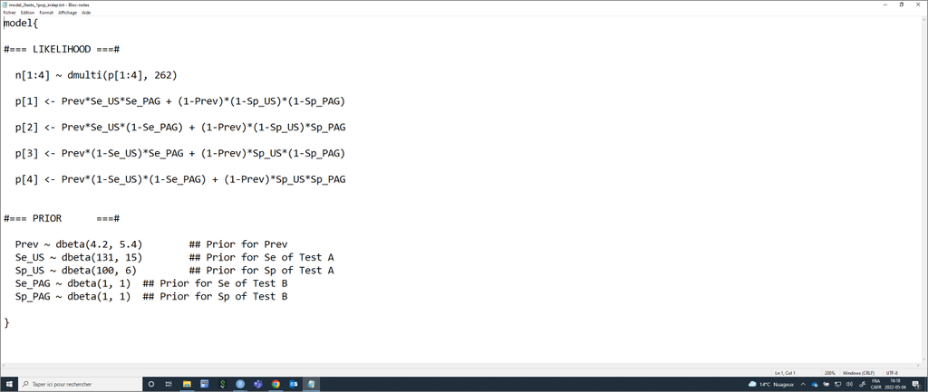

Text file with the model for 2 independent diagnostic tests in 1 single population.

We will also need to provide a list of initial values (one per Markov chain) for all unknown parameters.

```r
#Initializing values for the parameters Prev, and the Ses and Sps of the two tests for the 3 chains.
inits <- list(list(Prev=0.50,
              Se_US=0.90,
              Sp_US=0.90,
              Se_PAG=0.90,
              Sp_PAG=0.90),

              list(Prev=0.70,
              Se_US=0.10,
              Sp_US=0.10,
              Se_PAG=0.10,
              Sp_PAG=0.10),

              list(Prev=0.50,
              Se_US=0.50,
              Sp_US=0.50,
              Se_PAG=0.50,
              Sp_PAG=0.50)
              )
```

Now we can run the model using `jags()` function.

```r
library(R2jags)
library(coda)

#Run the Bayesian model
bug.out <- jags(data=datalist,
               model.file="model_2tests_1pop_indep.txt",
               parameters.to.save=c("Prev", "Se_US", "Sp_US", "Se_PAG", "Sp_PAG"),
               n.chains=3,
               inits=inits,
               n.iter=11000,
               n.burnin=1000,
               n.thin=1,
               DIC=FALSE)
```

Then we could produce the diagnostic plots, compute the ESS, and print out our results as we did previously (results not shown).

```r
library(mcmcplots)
bug.mcmc <- as.mcmc(bug.out)
mcmcplot(bug.mcmc, title="Diagnostic plots")
effectiveSize(bug.mcmc)
print(bug.out, digits.summary=3)
```

Or we could ask to plot the prior and posterior distributions of one (or many) of the parameters. Here, we asked for the prior and posterior distribution of *US* sensitivity.

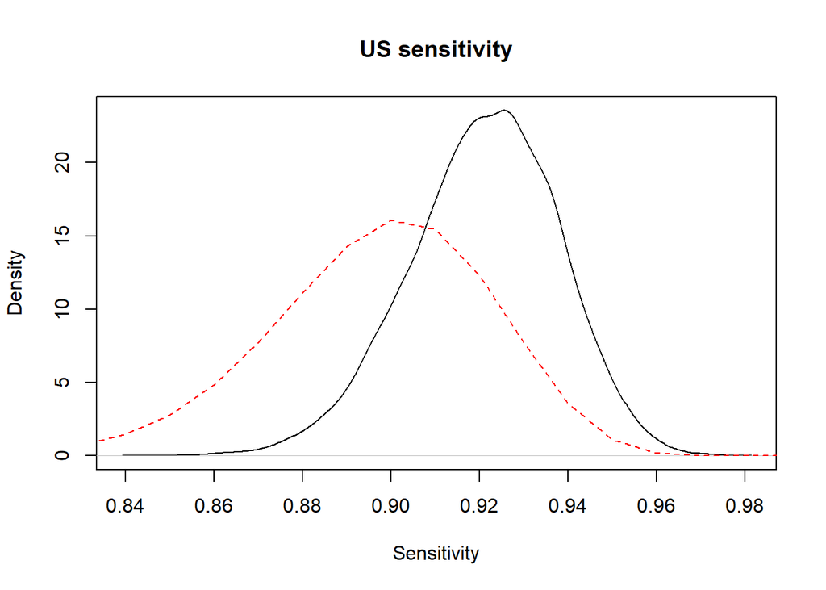

Prior (dashed red line) and posterior (full black line) distribution of US sensitivity.

```r
#Plot the posterior distribution
plot(density(x=bug.out$BUGSoutput$sims.list$Se_US),
     main="US sensitivity",
     xlab="Sensitivity", ylab="Density",
     )

#plot the prior distribution
curve(dbeta(x, shape1=Se.TestA.shapea, shape2=Se.TestA.shapeb), from=0, to=1,
      lty=2,
      col="red",
      add=TRUE)
```

## 5.2 Allowing for conditional dependence

We will not go into the exact details, but [Dendukuri and Joseph (2001)](https://onlinelibrary.wiley.com/doi/10.1111/j.0006-341X.2001.00158.x) developed a highly generalisable model structure that can account for conditional dependence between diagnostic tests. To allow for conditional dependence between tests, the likelihood function would be modified as follows, by adding covariance terms representing the conditional dependence between tests:

$n[1:4] \sim dmulti(P[1:4], n)$

$P1 = P*(SeA*SeB+covp) + (1-P)*((1-SpA)*(1-SpB)+covn)$  
$P2 = P*(SeA*(1-SeB)-covp) + (1-P)*((1-SpA)*SpB-covn)$  
$P3 = P*((1-SeA)*SeB-covp) + (1-P)*(SpA*(1-SpB)-covn)$  
$P3 = P*((1-SeA)*(1-SeB)+covp) + (1-P)*(SpA*SpB+covn)$

Thus, a small quantity (*covp*) is added to the sensitivities of the tests when they agree on a positive individual, and that same quantity is substracted when the tests disagree. *covp* thus represents the positive covariance between tests. Similarly, *covn* represents the negative covariance between tests. The effect of these covariances, if greater than zero, will be to penalize our estimates of the tests sensitivities and specificities to account for their conditional dependence.

Moreover, [Dendukuri and Joseph (2001)](https://onlinelibrary.wiley.com/doi/10.1111/j.0006-341X.2001.00158.x) proposed constraints on these covariance terms based on the inferred test sensitivities and specificities. This latter aspect allows to specify “natural limits” for the covariance terms prior distributions. Briefly, they demonstrated that:

- *covp* > $(1-SeA)*(SeB-1)$
- *covp* < (the minimum between $SeA$ and $SeB$) minus $SeA*SeB$
- *covn* > $(SpA-1)*(1-SpB)$
- *covn* < (the minimum between $SpA$ and $SpB$) minus $SpA*SpB$

Thus, we can use these as the minimum and maximum for *covp* and *covn*. For instance, we could use uniform distributions with these limits to describe the prior distributions for *covp* and *covn*. Our LCM would thus become:

```r
#Create the JAGS text file
model_2tests_1pop_dep <- paste0("model{

#=== LIKELIHOOD ===#

  n[1:4] ~ dmulti(p[1:4], ",n,")
  p[1] <- Prev*(Se_", TestA, "*Se_", TestB, " + covp) + (1-Prev)*((1-Sp_", TestA, ")*(1-Sp_", TestB, ") + covn)
  p[2] <- Prev*(Se_", TestA, "*(1-Se_", TestB, ") - covp) + (1-Prev)*((1-Sp_", TestA, ")*Sp_", TestB, " - covn)
  p[3] <- Prev*((1-Se_", TestA, ")*Se_", TestB, " - covp) + (1-Prev)*(Sp_", TestA, "*(1-Sp_", TestB, ") - covn)
  p[4] <- Prev*((1-Se_", TestA, ")*(1-Se_", TestB, ") + covp) + (1-Prev)*(Sp_", TestA, "*Sp_", TestB, " + covn)

#=== PRIOR  ===#

  Prev ~ dbeta(",Prev.shapea,", ",Prev.shapeb,")    ## Prior for Prev
  Se_", TestA, " ~ dbeta(",Se.TestA.shapea,", ",Se.TestA.shapeb,")  ## Prior for Se of Test A
  Sp_", TestA, " ~ dbeta(",Sp.TestA.shapea,", ",Sp.TestA.shapeb,")  ## Prior for Sp of Test A
  Se_", TestB, " ~ dbeta(",Se.TestB.shapea,", ",Se.TestB.shapeb,")  ## Prior for Se of Test B
  Sp_", TestB, " ~ dbeta(",Sp.TestB.shapea,", ",Sp.TestB.shapeb,")  ## Prior for Sp of Test B

#=== CONDITIONAL DEPENDENCE STRUCTURE ===#

  covp ~ dunif(minp,maxp)
  covn ~ dunif(minn,maxn)
  minp <- (1-Se_", TestA, ")*(Se_", TestB, "-1)
  minn <- (Sp_", TestA, "-1)*(1-Sp_", TestB, ")
  maxp <- min(Se_", TestA, ",Se_", TestB, ") - Se_", TestA, "*Se_", TestB, "
  maxn <- min(Sp_", TestA, ",Sp_", TestB, ") - Sp_", TestA, "*Sp_", TestB, "

}")

#write as a text (.txt) file
write.table(model_2tests_1pop_dep,
            file="model_2tests_1pop_dep.txt",
            quote=FALSE,
            sep="",
            row.names=FALSE,
             col.names=FALSE)
```

Again, with this code, you could simply modify the labels for Test A and Test B, and the shape parameters for the prior distributions and the text file with the JAGS model will automatically be updated. Currently, it looks like this:

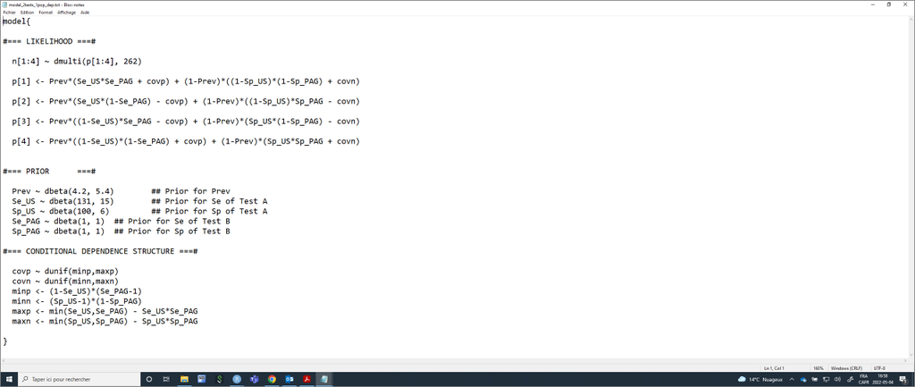

Text file with the model for 2 conditionally dependent diagnostic tests in 1 single population.

If we do not modify the other priors nor the dataset used previously we could run this model using the `jags()` function. However, we now have to add initial values for *covp* and *covn*. Also, note that we have added *covp* and *covn* to the list of parameters that we would like to monitor and we have increased substantially the number of iterations. The model allowing for conditional dependence between tests tends to be more difficult to solve. We will thus need a substantial number of iterations to get a decent ESS.

```r
#Initializing values for the parameters Prev, and the Ses and Sps of the two tests for the 3 chains.
inits <- list(list(Prev=0.50,
              Se_US=0.90,
              Sp_US=0.90,
              Se_PAG=0.90,
              Sp_PAG=0.90,
              covp=0,
              covn=0),

              list(Prev=0.70,
              Se_US=0.10,
              Sp_US=0.10,
              Se_PAG=0.10,
              Sp_PAG=0.10,
              covp=0.01,
              covn=0.01),

              list(Prev=0.50,
              Se_US=0.50,
              Sp_US=0.50,
              Se_PAG=0.50,
              Sp_PAG=0.50,
              covp=0.05,
              covn=0.05)
              )


library(R2jags)
library(coda)

#Run the Bayesian model
bug.out <- jags(data=datalist,
               model.file="model_2tests_1pop_dep.txt",
               parameters.to.save=c("Prev", "Se_US", "Sp_US", "Se_PAG", "Sp_PAG", "covp", "covn"),
               n.chains=3,
               inits=inits,
               n.iter=101000,
               n.burnin=1000,
               n.thin=1,
               DIC=FALSE)
```

Then we could produce the diagnostic plots, compute the ESS, and print out our results as we did previously (the diagnostic plots are not shown).

```r
library(mcmcplots)
bug.mcmc <- as.mcmc(bug.out)
mcmcplot(bug.mcmc, title="Diagnostic plots")
effectiveSize(bug.mcmc)
print(bug.out, digits.summary=3)
```

```r
effectiveSize(bug.mcmc)
```

```
##      Prev    Se_PAG     Se_US    Sp_PAG     Sp_US      covn      covp
## 15004.319  1958.066  5698.349  7304.412  7193.086  7093.277  1931.684
```

```r
print(bug.out, digits.summary=3)
```

```
## Inference for Bugs model at "model_2tests_1pop_dep.txt", fit using jags,
##  3 chains, each with 101000 iterations (first 1000 discarded)
##  n.sims = 300000 iterations saved
##        mu.vect sd.vect  2.5%   25%   50%   75% 97.5%  Rhat n.eff
## Prev     0.555   0.039 0.479 0.529 0.555 0.581 0.632 1.001 63000
## Se_PAG   0.948   0.035 0.872 0.924 0.953 0.978 0.998 1.001  7400
## Se_US    0.905   0.023 0.855 0.891 0.907 0.921 0.944 1.001 22000
## Sp_PAG   0.922   0.040 0.835 0.897 0.926 0.952 0.989 1.001 13000
## Sp_US    0.950   0.021 0.901 0.938 0.953 0.965 0.982 1.001 35000
## covn     0.033   0.020 0.002 0.018 0.031 0.045 0.077 1.001 66000
## covp     0.038   0.029 0.000 0.012 0.034 0.059 0.100 1.001  6800
##
## For each parameter, n.eff is a crude measure of effective sample size,
## and Rhat is the potential scale reduction factor (at convergence, Rhat=1).
```

The ESS is still just around 2,000 for some parameters (e.g., *Se_PAG*), if it was for publication, we would possibly let it run for more iterations.

# 6 Exercise 2 - Two tests

## 6.1 Questions

Open up the `R` project for Exercise 2 (i.e., the R project file named *Exercise 2.Rproj*).

In the Exercise 2 folder, you will find partially completed `R` scripts. To answer the questions, try to complete the missing parts (they are highlighted by a **#TO COMPLETE#** comment). We also provided complete `R` scripts, but try to work it out on your own first!

**1. Start from the partially completed *Question 1.R* script located in Exercise 2 folder.** We could try to estimate the Se and Sp of the PAG-based ELISA test when compared to US as the reference test. We could, however, explicitly acknowledge that the US exam is not a gold-standard test. At first, we could assume that these tests are conditionally independent. We will use data from one population (herd #1). In herd #1, the cross-tabulated PAG by US results were as follows:

**Table.** Cross-classified results of the PAG and US tests in herd #1.

[output not shown]

How many unknown parameters do you have to estimate and how many degrees of freedom do you have? Therefore, how many informative priors will you need? Estimate PAG’s Se and Sp, and true pregnancy prevalence using informative priors on US’ Se and Sp, and on pregnancy’s prevalence. Compare your results to those of Exercise 1 (question 4) where you estimated PAG’s Se and Sp, but assuming that US was a gold standard test.

**Some literature to help you with Informative priors:**  
In 2006, [Romano et al.](https://www.sciencedirect.com/science/article/pii/S0093691X06001543?via%3Dihub) reported, for a US exam conducted between 28-45 days post-insemination:  
-Se = 0.90 (95CI: 0.85, 0.95)  
-Sp = 0.95 (95CI: 0.90, 0.97)

Moreover, in a recent study conducted on 30 Canadian herds they reported an expected pregnancy prevalence of 42% with 97.5% percentile of 74%.

**2. Start from the `R` script that you completed in Question 1.** Now run the same model, but use vague priors on all unknown parameters. Do you think it will work? What do you observe regarding the Markov chains?

**3. Start from the partially completed *Question 3.R* script located in Exercise 2 folder.** Now, we could consider that some conditional dependency exist between the two tests. For instance, it was reported that PAG concentration is higher in first parity cows ([Ricci et al., 2015](https://doi.org/10.3168/jds.2014-8974), [Mercadante et al., 2016](https://doi.org/10.3168/jds.2015-10595)). US exams may also be easier to conduct on first parity cows and, thus, Se of both tests may be higher in first parity cows and lower in older cows. Build a model where conditional dependency is a possibility. How many unknown parameters and degrees of freedom do you have? Are your Markov chains behaving OK? What do you observe? Try to play with the number of iterations to reach an effective sample size (**ESS**) > 3,000. How are your results differing from that of question 1 (where you assumed conditional independence)?

## 6.2 Answers

**1.** We could try to estimate the Se and Sp of the PAG-based ELISA test using US as the reference test. We could, however, explicitly acknowledge that the US exam is not a gold-standard test. At first, we could assume that these tests are conditionally independent. How many unknown parameters do you have to estimate and how many degrees of freedom do you have? Therefore, how many informative priors will you need? Estimate PAG’s Se and Sp, and true pregnancy prevalence using informative priors on US’ Se and Sp, and on pregnancy’s prevalence. Compare your results to those of Exercise 1 (question 4) where you estimated PAG’s Se and Sp, but assuming that US was a gold standard test.

**Answer:** We now have 5 unknown parameters (PAG’s *Se* and *Sp*, US’ *Se* and *Sp*, and pregnancy prevalence, *P*) and we have 3 degrees of freedom (i.e., one 2x2 table where three cells are providing valuable information and the content of the 4th cell can be deduced from the total number of observations minus the content of the other three cells). Thus, we need informative priors for at least 2 parameters. As suggested, we will use informative priors for 3 parameters ( US’ *Se* and *Sp*, and *P*), so the model is identifiable.

**Table.** Results assuming **US is not perfect**

| **Parameters** | **Median** | **95CI** |
| --- | --- | --- |
| **PAG Se** | 0.993 | 0.968, 1.000 |
| **PAG Sp** | 0.979 | 0.922, 0.999 |
| **US Se** | 0.923 | 0.885, 0.955 |
| **US Sp** | 0.970 | 0.941, 0.987 |
| **Prevalence** | 0.554 | 0.493, 0.614 |

As a comparison, in question 4 of Exercise 1, where we assumed that US was a perfect test, we assumed that US *Se* and *Sp* was 1.0 and we estimated accuracy of PAG as:

**Table.** Results assuming **US is perfect**

| **Parameters** | **Median** | **95CI** |
| --- | --- | --- |
| **PAG Se** | 0.988 | 0.961, 0.998 |
| **PAG Sp** | 0.915 | 0.859, 0.955 |

Thus, the 10 cows that were PAG+ and US- where all considered to be a failure of the PAG test (i.e., False+ on PAG). This resulted in a lower estimated PAG specificity. Now that we indicated that US is not perfect, these disagreements are not exclusively attributed to the PAG test, hence the higher estimated PAG specificity.

**2.** Now run the same model, but use vague priors on all unknown parameters. Do you think it will work? What do you observe regarding the Markov chains?

**Answer:** Beforehand, we would say no, it will not work! We have 5 unknown parameters and only 3 degrees of freedom. The model is non-identifiable. With some data sets, though, it will sometimes work (if the number of potential solutions is very limited). This is the case here, there is so little disagreement between tests that the Markov chains were able to converge. However, they have a strange behaviour, for all parameters, we always have two chains converging in one area and another one converging at the exact opposite (see figure below). This is a case where we have a mirror solution. When such situation arise, we could consider adding informative priors for at least one other parameter (to make the model identifiable). However, remember that **mirror solutions may arise even in LCM that are identifiable**. In this latter case, we would have to exclude the Markov chain producing the “biologically impossible” results or to modify the set of initial values of the problematic Markov chain.

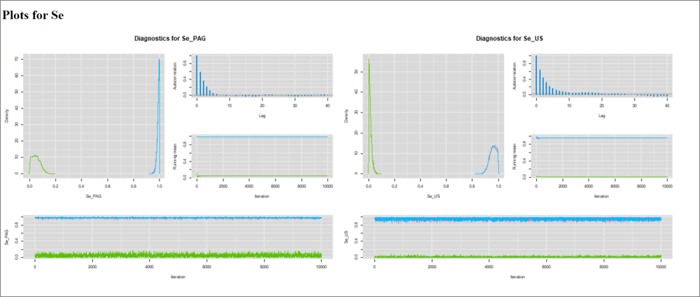

Diagnostic plot - Mirror solution

**3.** Build a model where conditional dependency is a possibility. How many unknown parameters and degrees of freedom do you have? Are your Markov chains behaving OK? What do you observe? Try to play with the number of iterations to reach an effective sample size (**ESS**) > 3,000. How are your results differing from that of question 1 (where you assumed conditional independence)?

**Answer:** We have 7 unkown parameters (PAG’s *Se* and *Sp*, US’ *Se* and *Sp*, *P*, *covp*, and *covn*). We still only have 3 degrees of freedom, so we need informative priors on 4 parameters. We can use the [Romano et al. (2006)](https://www.sciencedirect.com/science/article/pii/S0093691X06001543?via%3Dihub) derived priors for US’ *Se* and *Sp*, and use our pregnancy prevalence informative prior. We can use the natural bounds of *covp* and *covn* proposed by [Dendukuri and Joseph (2001)](https://onlinelibrary.wiley.com/doi/10.1111/j.0006-341X.2001.00158.x) as priors for these parameters.

We initially ran the LCM for 11,000 iterations (with a burn-in of 1,000). The Markov chains were still cycling up and down for some of the parameters (*Se_PAG* and *covp* were the worst; see *Se_PAG* below). But it is still cycling in a very tight space (i.e., check the Y-axis scale). Autocorrelation seems to be a problem (especially for *Se_pag* and *covp*, again).

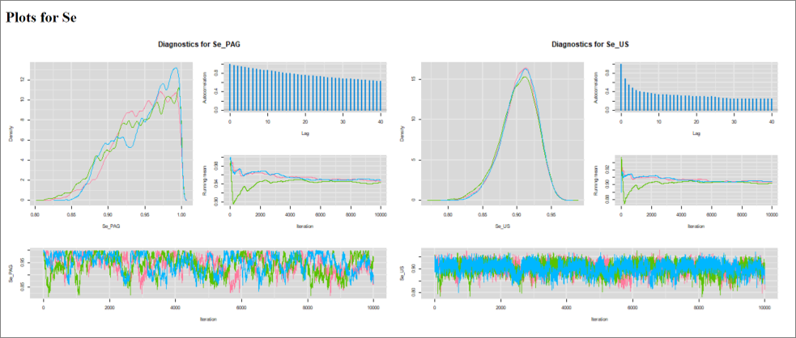

Diagnostic plot - 11,000 iterations

The ESS for these two parameters were both around 170. So, despite the 30,000 values (3 chains times 11,000 iterations, minus the 1,000 burn-in of each chain) stored during the Monte Carlo simulation, there is just the equivalent of 170 independent values. This would be quite a small sample to report with precision the median, 2.5th, and 97.5th estimates. Using the exact same model, but with a number of iteration of 201,000, we obtained ESS >3,500 for all parameters.

**Table.** Results of the LCM assuming or not conditional independence between diagonstic tests.

|  | **Conditional independence LCM** |  |  | **Conditional dependence LCM** |  |
| --- | --- | --- | --- | --- | --- |
| **Parameters** | **Median** | **95CI** |  | **Median** | **95CI** |
| **PAG Se** | 0.993 | 0.968, 1.00 |  | 0.952 | 0.866, 0.998 |
| **PAG Sp** | 0.979 | 0.922, 0.999 |  | 0.924 | 0.833, 0.988 |
| **US Se** | 0.923 | 0.885, 0.955 |  | 0.906 | 0.847, 0.947 |
| **US Sp** | 0.970 | 0.941, 0.987 |  | 0.951 | 0.899, 0.981 |
| **covp** | NA | NA |  | 0.035 | 0.000, 0.104 |
| **covn** | NA | NA |  | 0.032 | 0.002, 0.079 |
| **Prevalence** | 0.554 | 0.493, 0.614 |  | 0.555 | 0.479, 0.634 |

When we compare the LCM assuming or not conditional independence, we can see that the tests’ Se and Sp estimates are slightly lower in the model allowing for conditional dependence. Indeed, in that model the covariance terms, *covp* and *covn*, where small, but positive. Remember, in the model allowing for conditional dependence, the agreement between tests is now due to the PAG and US accuracy parameters (e.g., their Se) **plus a small value** due to their covariance (e.g., *covp*). Therefore, the tests accuracy parameters estimates will be reduced as their covariance is increased.

# 7 Multiple populations

In some situations, the diagnostic tests will be applied in two or more populations with different disease prevalence. In such cases, it could be reasonable to assume that:

- The prevalence varies from one population to another
- The tests Se and Sp are constant from one population to another

It could then be advantageous to model the different populations simultaneously in a same LCM as described by [Hui and Walter (1980)](https://www.jstor.org/stable/2530508?seq=1). With two populations, we would have six unknown parameters (*SeA* and *SpA*, *SeB* and *SpB*, and each population’s prevalence, *P1* and *P2*). When conducting two diagnostic tests in two populations, the data generated can be presented as two 2x2 tables presenting the cross-classified results of the two tests.

**Table.** Cross-classified results from two diagnostic tests in two populations.

| **Population 1** |  |  |  | **Population 2** |  |  |
| --- | --- | --- | --- | --- | --- | --- |
|  | **Test A+** | **Test A-** |  |  | **Test A+** | **Test A-** |
| **Test B+** | Pop1 n1 | Pop1 n3 |  | **Test B+** | Pop2 n1 | Pop2 n3 |
| **Test B-** | Pop1 n2 | Pop1 n4 |  | **Test B-** | Pop2 n2 | Pop2 n4 |

We can see from these 2x2 tables that we have 6 degrees of freedom available. Indeed, in each of the 2x2 table, we have three cells that do contribute a valuable information and the information in the 4th cell can be “guessed” using the total number of observations minus the content of the other three cells. The model proposed by [Hui and Walter (1980)](https://www.jstor.org/stable/2530508?seq=1) is, therefore, barely identifiable.

[Cheung et al. (2021)](https://doi.org/10.20506/rst.40.1.3224) have described how the number of unknown parameters and degrees of freedom vary as function of the number of populations studied when comparing two conditionally independent diagnostic tests (see below).

**Table.** Number of degrees of freedom and of unknown parameters when comparing two conditionally independent diagnostic tests across various number of populations (adapted from [Cheung et al. (2021)](https://doi.org/10.20506/rst.40.1.3224)).

| **Number of Populations** | **Number of unknown parameters (np)** | **Number of degrees of freedom (df)** | **Minimum number of informative priors needed** |
| --- | --- | --- | --- |
| 1 | 5 | 3 | 2 |
| 2 | 6 | 6 | 0 |
| 3 | 7 | 9 | 0 |
| 4 | 8 | 12 | 0 |
| p | 4+p | 3*p | if df < np, then np-df |

## 7.1 Likelihood function with 2 (or more) populations

With two populations, the likelihood function that could be used to link the observed data (*Pop1 n1*, *Pop1 n2*, …, *Pop2 n4*) to the unknown parameters (*SeA* and *SpA*, *SeB* and *SpB*, and *P1* and *P2*) can be described as follows:

$Ppop1[1:4] \sim dmulti(Pop1[1:4], nPop1)$  
$Ppop1_1 = P1*SeA*SeB + (1-P1)*(1-SpA)*(1-SpB)$  
$Ppop1_2 = P1*SeA*(1-SeB) + (1-P1)*(1-SpA)*SpB$  
$Ppop1_3 = P1*(1-SeA)*SeB + (1-P1)*SpA*(1-SpB)$  
$Ppop1_4 = P1*(1-SeA)*(1-SeB) + (1-P1)*SpA*SpB$

$Ppop2[1:4] \sim dmulti(Pop2[1:4], nPop2)$  
$Ppop2_1 = P2*SeA*SeB + (1-P2)*(1-SpA)*(1-SpB)$  
$Ppop2_2 = P2*SeA*(1-SeB) + (1-P2)*(1-SpA)*SpB$  
$Ppop2_3 = P2*(1-SeA)*SeB + (1-P2)*SpA*(1-SpB)$  
$Ppop2_4 = P2*(1-SeA)*(1-SeB) + (1-P2)*SpA*SpB$

Where $Ppop1_1$ to $Ppop1_4$ and $Ppop2_1$ to $Ppop2_4$ are the probabilities of falling in a given cell of the 2x2 table in population 1 and population 2, respectively; and $nPop1$ and $nPop2$ are the number of individuals tested in population 1 and 2, respectively. Thus, if you look carefully, **we simply duplicated the likelihood function used before and we added subscripts to differentiate the cells, probabilities, and disease prevalence of the two populations.** Cool hey? If you have three, four, etc populations, you can then extend the likelihood function to include them.

## 7.2 Organizing the data with 2 (or more) populations

To run such a model, we simply need to provide, for each population, a dataset where *n1*, *n2*, *n3*, and *n4* are listed (in that order). For instance, if we use herd #1 and herd #2 from the PAG *vs.* US study, we have the following 2x2 tables:

**Table.** Cross-classified results from the PAG and US diagnostic tests in herd #1 and herd #2.

| **Herd 1** |  |  | **Total** |  | **Herd 2** |  |  | **Total** |
| --- | --- | --- | --- | --- | --- | --- | --- | --- |
|  | **US+** | **US-** |  |  |  | **US+** | **US-** |  |
| **PAG+** | 138 | 10 |  |  | **PAG+** | 71 | 8 |  |
| **PAG-** | 1 | 113 |  |  | **PAG-** | 0 | 69 |  |
| **Total** |  |  | 262 |  | **Total** |  |  | 148 |

The dataset could, thus be created as follows:

```r
#n is of the form : (TestA pos and TestB pos), (TestA pos and TestB neg), (TestA neg and TestB pos), then (TestA neg and TestB neg)
datalist <- list(Pop1=c(138,1,10,113),
                 Pop2=c(71, 0, 8, 69)
                 )
```

## 7.3 The JAGS model with 2 (or more) populations

We could provide the values that will be used to described the prior distributions as we did before (so they are included in the model text file). The only difference is that we now have two prevalence parameters (*P1* and *P2*) to describe. In the example below, I will use vague priors for all parameters (just because we can!).

```r
#We could first create labels for TestA and TestB
TestA <- "US"
TestB <- "PAG"

#Provide information for the prior distributions (all beta distributions) for the 6 unknown parameters
Prev1.shapea <- 1         #a shape parameter for Prev in population 1
Prev1.shapeb <- 1         #b shape parameter for Prev in population 1

Prev2.shapea <- 1         #a shape parameter for Prev in population 2
Prev2.shapeb <- 1         #b shape parameter for Prev in population 2

Se.TestA.shapea <- 1     #a shape parameter for Se of TestA
Se.TestA.shapeb <- 1     #b shape parameter for Se of TestA
Sp.TestA.shapea <- 1     #a shape parameter for Sp of TestA
Sp.TestA.shapeb <- 1     #b shape parameter for Sp of TestA

Se.TestB.shapea <- 1     #a shape parameter for Se of TestB
Se.TestB.shapeb <- 1     #b shape parameter for Se of TestB
Sp.TestB.shapea <- 1     #a shape parameter for Sp of TestB
Sp.TestB.shapeb <- 1     #b shape parameter for Sp of TestB

#I will also need the total number of individuals tested in each population (nPop1 and nPop2)
n <- sapply(datalist, sum)
nPop1 <- n[1]
nPop2 <- n[2]
```

With that, we have everything that is needed to write the JAGS model.

```r
#Create the JAGS text file
model_2tests_2pop_indep <- paste0("model{

#=== LIKELIHOOD ===#

  #=== POPULATION 1 ===#
  Pop1[1:4] ~ dmulti(p1[1:4], ",nPop1,")
  p1[1] <- Prev1*Se_", TestA, "*Se_", TestB, " + (1-Prev1)*(1-Sp_", TestA, ")*(1-Sp_", TestB, ")
  p1[2] <- Prev1*Se_", TestA, "*(1-Se_", TestB, ") + (1-Prev1)*(1-Sp_", TestA, ")*Sp_", TestB, "
  p1[3] <- Prev1*(1-Se_", TestA, ")*Se_", TestB, " + (1-Prev1)*Sp_", TestA, "*(1-Sp_", TestB, ")
  p1[4] <- Prev1*(1-Se_", TestA, ")*(1-Se_", TestB, ") + (1-Prev1)*Sp_", TestA, "*Sp_", TestB, "

  #=== POPULATION 2 ===#
  Pop2[1:4] ~ dmulti(p2[1:4], ",nPop2,")
  p2[1] <- Prev2*Se_", TestA, "*Se_", TestB, " + (1-Prev2)*(1-Sp_", TestA, ")*(1-Sp_", TestB, ")
  p2[2] <- Prev2*Se_", TestA, "*(1-Se_", TestB, ") + (1-Prev2)*(1-Sp_", TestA, ")*Sp_", TestB, "
  p2[3] <- Prev2*(1-Se_", TestA, ")*Se_", TestB, " + (1-Prev2)*Sp_", TestA, "*(1-Sp_", TestB, ")
  p2[4] <- Prev2*(1-Se_", TestA, ")*(1-Se_", TestB, ") + (1-Prev2)*Sp_", TestA, "*Sp_", TestB, "


#=== PRIOR  ===#

  Prev1 ~ dbeta(",Prev1.shapea,", ",Prev1.shapeb,")     ## Prior for Prevalence in population 1
  Prev2 ~ dbeta(",Prev2.shapea,", ",Prev2.shapeb,")     ## Prior for Prevalence in population 2
  Se_", TestA, " ~ dbeta(",Se.TestA.shapea,", ",Se.TestA.shapeb,")  ## Prior for Se of Test A
  Sp_", TestA, " ~ dbeta(",Sp.TestA.shapea,", ",Sp.TestA.shapeb,")  ## Prior for Sp of Test A
  Se_", TestB, " ~ dbeta(",Se.TestB.shapea,", ",Se.TestB.shapeb,")  ## Prior for Se of Test B
  Sp_", TestB, " ~ dbeta(",Sp.TestB.shapea,", ",Sp.TestB.shapeb,")  ## Prior for Sp of Test B

}")

#write as a text (.txt) file
write.table(model_2tests_2pop_indep,
            file="model_2tests_2pop_indep.txt",
            quote=FALSE,
            sep="",
            row.names=FALSE,
            col.names=FALSE)
```

With this code, you could, again, simply modify the labels for Test A and Test B, and the shape parameters for the prior distributions. The text file with the JAGS model will automatically be updated. Currently, it looks like this:

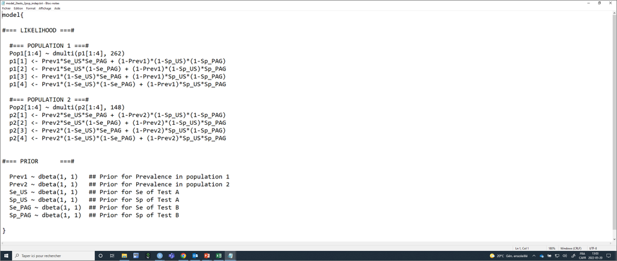

Text file with the model for 2 independent diagnostic tests applied to two populations.

Again, we will need to provide a list of initial values (one per Markov chain) for all unknown parameters. Careful again, we now have two prevalence (*Prev1* and *Prev2*).

```r
#Initializing values for the parameters Prev, and the Ses and Sps of the two tests for the 3 chains.
inits <- list(list(Prev1=0.50,
              Prev2=0.50,
              Se_US=0.90,
              Sp_US=0.90,
              Se_PAG=0.90,
              Sp_PAG=0.90),

              list(Prev1=0.60,
              Prev2=0.60,
              Se_US=0.80,
              Sp_US=0.80,
              Se_PAG=0.80,
              Sp_PAG=0.80),

              list(Prev1=0.40,
              Prev2=0.40,
              Se_US=0.70,
              Sp_US=0.70,
              Se_PAG=0.70,
              Sp_PAG=0.70)
              )
```

We can run the model using `jags()` function as seen before.

```r
library(R2jags)
library(coda)

#Run the Bayesian model
bug.out <- jags(data=datalist,
               model.file="model_2tests_2pop_indep.txt",
               parameters.to.save=c("Prev1", "Prev2", "Se_US", "Sp_US", "Se_PAG", "Sp_PAG"),
               n.chains=3,
               inits=inits,
               n.iter=11000,
               n.burnin=1000,
               n.thin=1,
               DIC=FALSE)
```

Then we could produce the diagnostic plots, compute the ESS, and print out our results as we did previously (results not shown).

```r
library(mcmcplots)
bug.mcmc <- as.mcmc(bug.out)
mcmcplot(bug.mcmc, title="Diagnostic plots")
effectiveSize(bug.mcmc)
print(bug.out, digits.summary=3)
```

## 7.4 Conditional dependence

As discussed before, an important assumption of the LCM described in the preceding section is that diagnostic tests are conditionally independent. This assumption, however, can be relaxed using the method proposed by [Dendukuri and Joseph (2001)](https://onlinelibrary.wiley.com/doi/10.1111/j.0006-341X.2001.00158.x). Note that, we are now increasing the number of unknown parameters and we will, therefore, have to provide additional informative distributions.

**Table.** Number of degrees of freedom and of unknown parameters when comparing two **conditionally dependent** diagnostic tests across various number of populations (adapted from [Cheung et al. (2021)](https://doi.org/10.20506/rst.40.1.3224)).

| **Number of Populations** | **Number of unknown parameters (np)** | **Number of degrees of freedom (df)** | **Minimum number of informative priors needed** |
| --- | --- | --- | --- |
| 1 | 7 | 3 | 4 |
| 2 | 8 | 6 | 2 |
| 3 | 9 | 9 | 0 |
| 4 | 10 | 12 | 0 |
| p | 4+2+p | 3*p | if df < np, then np-df |

For this example, in addition to specifying priors for *covp* and *covn*, I will add informative priors on US *Se* and *Sp*.

```r
library(epiR)
# US sensitivity ----------------------------------------------------------
# Sensitivity of US:  Mode=0.90, and we are 97.5% sure >0.85
Se.US <- epi.betabuster(mode=0.90, conf=0.975, greaterthan=T, x=0.85)

# US specificity ----------------------------------------------------------
# Specificity of US:  Mode=0.95, and we are 97.5% sure >0.90
Sp.US <- epi.betabuster(mode=0.95, conf=0.975, greaterthan=T, x=0.90)

Se.TestA.shapea <- Se.US$shape1     #a shape parameter for Se of TestA
Se.TestA.shapeb <- Se.US$shape2     #b shape parameter for Se of TestA
Sp.TestA.shapea <- Sp.US$shape1     #a shape parameter for Sp of TestA
Sp.TestA.shapeb <- Sp.US$shape2     #b shape parameter for Sp of TestA
```

The model would then be modified as follows (we simply added the *covp* and *covn* parameters in the likelihood function, and specified prior distributions for these):

```r
#Create the JAGS text file
model_2tests_2pop_dep <- paste0("model{

#=== LIKELIHOOD ===#

  #=== POPULATION 1 ===#
  Pop1[1:4] ~ dmulti(p1[1:4], ",nPop1,")
  p1[1] <- Prev1*(Se_", TestA, "*Se_", TestB, " + covp) + (1-Prev1)*((1-Sp_", TestA, ")*(1-Sp_", TestB, ") + covn)
  p1[2] <- Prev1*(Se_", TestA, "*(1-Se_", TestB, ") - covp) + (1-Prev1)*((1-Sp_", TestA, ")*Sp_", TestB, " - covn)
  p1[3] <- Prev1*((1-Se_", TestA, ")*Se_", TestB, " - covp) + (1-Prev1)*(Sp_", TestA, "*(1-Sp_", TestB, ") - covn)
  p1[4] <- Prev1*((1-Se_", TestA, ")*(1-Se_", TestB, ") + covp) + (1-Prev1)*(Sp_", TestA, "*Sp_", TestB, " + covn)

  #=== POPULATION 2 ===#
  Pop2[1:4] ~ dmulti(p2[1:4], ",nPop2,")
  p2[1] <- Prev2*(Se_", TestA, "*Se_", TestB, " + covp) + (1-Prev2)*((1-Sp_", TestA, ")*(1-Sp_", TestB, ") + covn)
  p2[2] <- Prev2*(Se_", TestA, "*(1-Se_", TestB, ") - covp) + (1-Prev2)*((1-Sp_", TestA, ")*Sp_", TestB, " - covn)
  p2[3] <- Prev2*((1-Se_", TestA, ")*Se_", TestB, " - covp) + (1-Prev2)*(Sp_", TestA, "*(1-Sp_", TestB, ") - covn)
  p2[4] <- Prev2*((1-Se_", TestA, ")*(1-Se_", TestB, ") + covp) + (1-Prev2)*(Sp_", TestA, "*Sp_", TestB, " + covn)



#=== PRIOR  ===#

  Prev1 ~ dbeta(",Prev1.shapea,", ",Prev1.shapeb,")     ## Prior for Prevalence in population 1
  Prev2 ~ dbeta(",Prev2.shapea,", ",Prev2.shapeb,")     ## Prior for Prevalence in population 2
  Se_", TestA, " ~ dbeta(",Se.TestA.shapea,", ",Se.TestA.shapeb,")  ## Prior for Se of Test A
  Sp_", TestA, " ~ dbeta(",Sp.TestA.shapea,", ",Sp.TestA.shapeb,")  ## Prior for Sp of Test A
  Se_", TestB, " ~ dbeta(",Se.TestB.shapea,", ",Se.TestB.shapeb,")  ## Prior for Se of Test B
  Sp_", TestB, " ~ dbeta(",Sp.TestB.shapea,", ",Sp.TestB.shapeb,")  ## Prior for Sp of Test B

  #=== CONDITIONAL DEPENDENCE STRUCTURE ===#

  covp ~ dunif(minp,maxp)
  covn ~ dunif(minn,maxn)
  minp <- (1-Se_", TestA, ")*(Se_", TestB, "-1)
  minn <- (Sp_", TestA, "-1)*(1-Sp_", TestB, ")
  maxp <- min(Se_", TestA, ",Se_", TestB, ") - Se_", TestA, "*Se_", TestB, "
  maxn <- min(Sp_", TestA, ",Sp_", TestB, ") - Sp_", TestA, "*Sp_", TestB, "

}")

#write as a text (.txt) file
write.table(model_2tests_2pop_dep,
            file="model_2tests_2pop_dep.txt",
            quote=FALSE,
            sep="",
            row.names=FALSE,
            col.names=FALSE)
```

This text file looks like this:

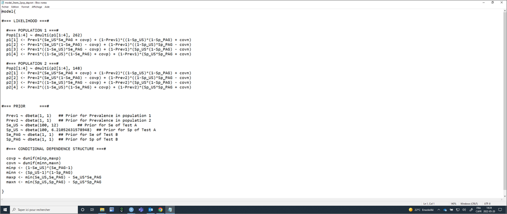

Text file with the model for 2 DEPENDENT diagnostic tests applied to two populations.

Again, the list of initial values will have to be modified to include (*covp* and *covn*).

```r
#Initializing values for the parameters Prev, and the Ses and Sps of the two tests for the 3 chains.
inits <- list(list(Prev1=0.50,
              Prev2=0.50,
              Se_US=0.90,
              Sp_US=0.90,
              Se_PAG=0.90,
              Sp_PAG=0.90,
              covp=0.0,
              covn=0.0),

              list(Prev1=0.60,
              Prev2=0.60,
              Se_US=0.80,
              Sp_US=0.80,
              Se_PAG=0.80,
              Sp_PAG=0.80,
              covp=0.01,
              covn=0.01),

              list(Prev1=0.40,
              Prev2=0.40,
              Se_US=0.70,
              Sp_US=0.70,
              Se_PAG=0.70,
              Sp_PAG=0.70,
              covp=0.05,
              covn=0.05)
              )
```

And, when running the model using `jags()`, we would also ask to monitor *covp* and *covn*. Note that I have increased the number of iterations / burn-in period (remember the autocorrelation problem seen with LCM with a covariance between test?).

```r
library(R2jags)
library(coda)

#Run the Bayesian model
bug.out <- jags(data=datalist,
               model.file="model_2tests_2pop_dep.txt",
               parameters.to.save=c("Prev1", "Prev2", "Se_US", "Sp_US", "Se_PAG", "Sp_PAG", "covp", "covn"),
               n.chains=3,
               inits=inits,
               n.iter=210000,
               n.burnin=10000,
               n.thin=1,
               DIC=FALSE)
```

Then we could produce the diagnostic plots, compute the ESS, and print out our results as we did previously (results not shown).

```r
library(mcmcplots)
bug.mcmc <- as.mcmc(bug.out)
mcmcplot(bug.mcmc, title="Diagnostic plots")
effectiveSize(bug.mcmc)
print(bug.out, digits.summary=3)
```

# 8 Exercise 3 - Mulitple populations

## 8.1 Questions

Open up the `R` project for Exercise 3 (i.e., the R project file named *Exercise 3.Rproj*).

In the Exercise 3 folder, you will find partially completed `R` scripts. To answer the questions, try to complete the missing parts (they are highlighted by a **#TO COMPLETE#** comment). We also provided complete `R` scripts, but try to work it out on your own first!

**1. Start from the partially completed *Question 1.R* script located in Exercise 3 folder.**